# Olist E-Commerce Strategic Audit (2016–2018)

## Introduction

This project presents **a comprehensive, data-driven audit of Olist** (major Brazilian marketplace), utilizing a dataset of 100,000 orders to extract actionable business intelligence. By transitioning from raw data to high-level strategic KPIs, the project identifies the critical challenges and growth drivers that defined the platform's performance during its primary expansion phase.

The initial phase (Q1) focuses on Seller Performance, specifically isolating **Market Leaders** to benchmark their reliability against the broader marketplace. Through the development of custom SQL views and longitudinal ranking models, the analysis reveals deep-seated logistical volatility. It highlights how even high-volume powerhouse sellers can frequently underperform compared to the market average, creating significant brand risk and customer dissatisfaction.

The second pillar (Q2) explores Market Positioning and Revenue Concentration. By intersecting sales volume with median product pricing and applying regression analysis, the project identifies **High-Yield categories** - segments that generate disproportionate revenue relative to their logistical footprint. This section utilizes price tiering and Pareto-style segmentation to visualize the platform's dependency on a narrow group of top-performing categories.

The thrid chapter addresses Geographical Logistics and Financial Exposure (Q3). By mapping delivery accuracy and speed across Brazil's diverse states, the analysis **identifies infrastructure bottlenecks**. It concludes by quantifying Revenue at Risk.

The final phase (Q4) synthesizes the audit through Market Growth Trajectory and Revenue Momentum. By calculating Month-over-Month (MoM) growth rates and trailing 3-month averages, the analysis evaluates the **platform's overall scalability**. It identifies whether growth is driven by sustainable market expansion or isolated seasonal peaks, providing a forward-looking assessment of the platform's health.

This multi-layered approach ensures that technical data findings are always anchored in business reality, offering a professional template for e-commerce performance management.

**External Data Source**

The primary analytical source of this audit is the [Olist E-Commerce Public Dataset](https://www.kaggle.com/datasets/olistbr/brazilian-ecommerce) (André Sionek, 2018), which contains 100,000 anonymized orders from 2016 to 2018 across the Brazilian marketplace, available from Kaggle under *CC BY-NC-SA 4.0*.

**Already Achieved**

The project has successfully executed Pre-Staging and ETL (Extract, Transform, Load) lifecycle. This phase was split into two critical workstreams:

- **Python-Based Pre-Staging** (*ecommerce_converter.py*): prior to database ingestion, a custom Python pipeline was executed to handle encoding detection and Unicode normalization. This involved transliterating special characters and standardizing raw CSV assets into a unified UTF-8 format, ensuring global data compatibility;
- **PostgreSQL ETL & Data Modeling** (*ecommerce_ETL.sql*): the sanitized data was migrated into a structured relational environment. Raw tables were cleaned, normalized, and transformed into high-performance analytical views, ensuring the data is primed for high-level business intelligence.

```python
import os
from scipy import stats
import numpy as np
import pandas as pd
import seaborn as sns
import matplotlib.pyplot as plt
from matplotlib.path import Path
from pandas.plotting import table
import matplotlib.font_manager as fm
import matplotlib.ticker as mtick
from dotenv import load_dotenv
from sqlalchemy import create_engine

load_dotenv()

%matplotlib inline
%load_ext sql
%reload_ext sql
%config SqlMagic.autopandas = True
%config SqlMagic.named_parameters="enabled"
%config SqlMagic.displaylimit = 50
%config SqlMagic.feedback = False

BASE_DIR = os.getcwd()
STYLE_PATH = os.path.join(BASE_DIR, 'custom.mplstyle')
FIGURES_PATH = os.path.join(BASE_DIR, 'figures')
DATA_PATH = os.path.join(BASE_DIR, 'data')
FONT_PATH = os.path.join('assets', 'fonts', 'Ubuntu-Regular.ttf')

plt.style.use(STYLE_PATH)
full_palette = plt.rcParams["axes.prop_cycle"].by_key()["color"]
pd.options.display.precision = 3

if os.path.exists(FONT_PATH):
    fe = fm.FontEntry(
        fname = FONT_PATH,
        name = 'ProjectUbuntu'
    )
    fm.fontManager.ttflist.insert(0, fe)
    plt.rcParams['font.family'] = fe.name
else:
    print("Warning: Font file not found. Falling back to sans-serif.")
    plt.rcParams['font.family'] = 'sans-serif'

# ----------------- pgAdmin setup -----------------
PG_USER     = os.getenv("PG_USER")
PG_PASSWORD = os.getenv("PG_PASSWORD")
PG_HOST     = os.getenv("PG_HOST")
PG_PORT     = os.getenv("PG_PORT")
PG_DBNAME   = os.getenv("PG_DBNAME")
# ----------------------------------------------------------

DB_URL = f"postgresql+psycopg2://{PG_USER}:{PG_PASSWORD}@{PG_HOST}:{PG_PORT}/{PG_DBNAME}"
engine = create_engine(DB_URL)
```

```
The sql extension is already loaded. To reload it, use:
  %reload_ext sql
```

```python
def save_df_as_png(df, path):
    fig_height = 0.5 + (len(df) * 0.4)
    fig, ax = plt.subplots(figsize=(10, fig_height))
    ax.axis('off')

    tbl = table(ax, df, loc='center', cellLoc='center')

    tbl.auto_set_font_size(False)
    tbl.set_fontsize(10)
    tbl.scale(1.2, 1.8)

    for (row, col), cell in tbl.get_celld().items():
        if row == 0:
            cell.set_text_props(weight='bold', color='white')
            cell.set_facecolor("#516462")
            cell.set_edgecolor('#516462')
        else:
            cell.set_facecolor("#ffffff")
            cell.set_edgecolor('#EEEEEE')
        if col == -1:
            cell.set_text_props(ha='left')

    plt.savefig(path, dpi=300, bbox_inches='tight', transparent=True)
    plt.close()
```

**Environment Setup & Database Connectivity**

The initial cells establish the technical foundation for the audit by initializing the analytical environment and securing data access:

- Analytical Stack: imports *pandas* and *scipy* for statistical computation, alongside *seaborn* and *matplotlib* for high-fidelity visualization;
- Visual Standards: applies a *custom.mplstyle* and the ProjectUbuntu font family to maintain branding consistency across all figures;
- SQL Engine & Magic Workflow: utilizes *SQLAlchemy* with the *psycopg2* driver to connect to the local ecommerce PostgreSQL instance; configures *%sql* magics to pipe query results directly into pandas DataFrames, enabling a seamless transition from raw relational data to Python-based analysis.

**Technical Implementation Details**

- Database Access & Secure Infrastructure: the connection string uses postgresql+psycopg2 to interface with author's user profile on the database; industry-standard security protocols are implemented by decoupling sensitive database credentials from the code (*.env*) and *python-dotenv*).
- Visualization Scaling: the *STYLE_PATH* and *FIGURES_PATH* variables ensure that all saved .png assets (including dataframes saved via *save_df_as_png*) follow the same directory logic and resolution.
- Data Precision: *pd.options.display.precision = 3* is set globally to keep financial metrics and percentages concise within the audit's tables.

```python
%%sql engine
SELECT table_name AS view_name
FROM information_schema.tables
WHERE table_schema = 'analytics'
ORDER BY table_name;
```

|  | view_name |
| --- | --- |
| 0 | int_leaders_late_delivery_count |
| 1 | int_market_leaders |
| 2 | rpt_q1_leaders_l6m_late_delivery_rate |
| 3 | rpt_q1_leaders_market_share |
| 4 | rpt_q1_leaders_market_share_delay_risk |
| 5 | rpt_q1_leaders_monthly_ldr_segmentation |
| 6 | rpt_q1_seller_delivery_delay_segmentation |
| 7 | rpt_q1_seller_quarterly_performance |
| 8 | rpt_q2_product_category_performance |
| 9 | rpt_q2_top_categories_in_revenue |
| 10 | rpt_q2_top_categories_in_revenue_priceband |
| 11 | rpt_q3_state_delivery_estimation_reliability |
| 12 | rpt_q4_leaders_mom_growth |

This SQL serves as a validation step to ensure that all required analytical layers are correctly registered within the PostgreSQL instance. The query filters for the analytics schema, which houses the transformed business views, separating them from the raw transactional tables. It provides a quick inventory of the custom-built views (e.g., those handling seller ranks or geographic deltas).

## Q1 Seller Performance & Delivery Delays Over Time

This section establishes the competitive landscape of the marketplace by showing top-tier players and their operational reliability:

- **Q1.1** identifies who the market Leaders are and what are their quarterly transaction scale;
- **Q1.2** benchmarks the volume of Leaders against the Residual market average to show the scale of dominance;
- **Q1.3** categorizes the entire market into Risk Tiers based on Late Delivery Rates (LDR);
- **Q1.4** evaluates if Leaders maintain high-end logistics or if scale comes at the cost of reliability.

### Q1.1 Quarterly Order Volume by Seller Performance Tier

```python
%%sql
--DROP VIEW IF EXISTS analytics.rpt_q1_seller_quarterly_performance;
CREATE OR REPLACE VIEW analytics.rpt_q1_seller_quarterly_performance AS
WITH seller_periodic_volume AS (
    SELECT
        foi.seller_sk,
        COUNT(DISTINCT o.order_sk) AS order_volume,
        (EXTRACT(YEAR FROM order_purchase_t)::TEXT || '.Q' || EXTRACT(quarter FROM order_purchase_t)::TEXT) AS quarterly
    FROM
        fact_order_items foi
        LEFT JOIN dim_orders o ON foi.order_sk = o.order_sk
    GROUP BY
        foi.seller_sk,
        (EXTRACT(YEAR FROM order_purchase_t)::TEXT || '.Q' || EXTRACT(quarter FROM order_purchase_t)::TEXT)
), market_volume_thresholds AS (
    SELECT
        quarterly,
        PERCENTILE_CONT(0.25) WITHIN GROUP (ORDER BY order_volume) AS vol_p25,
        PERCENTILE_CONT(0.75) WITHIN GROUP (ORDER BY order_volume) AS vol_p75
    FROM seller_periodic_volume
    GROUP BY quarterly
)
SELECT
    spv.seller_sk AS seller_id,
    spv.order_volume,
    spv.quarterly,
    mvt.vol_p25,
    mvt.vol_p75,
    CASE WHEN spv.order_volume > mvt.vol_p75 THEN '3 - high'
         WHEN spv.order_volume < mvt.vol_p25 THEN '1 - low'
         ELSE '2 - mid' END AS performance_tier
FROM
    seller_periodic_volume spv
    LEFT JOIN market_volume_thresholds mvt ON spv.quarterly = mvt.quarterly
ORDER BY spv.quarterly, spv.seller_sk;
```

```python
df_q111 = pd.read_sql("SELECT * FROM analytics.rpt_q1_seller_quarterly_performance;", engine)
```

**SQL Logic**

View: *rpt_q1_seller_quarterly_performance*

To assess seller performance, I implemented a dynamic tiering that categorizes sellers based on their quarterly order volume relative to the market:

- Temporal Grain: I used **EXTRACT()** function with string manipulation, resulting in standardized YYYY.QQ fiscal quarter identifier;
- Aggregation: I calculated **DISTINCT** order count per seller per fiscal quarter to focus on unique customer transactions;
- Dynamic Thresholding: I used window-based percentiles using **PERCENTILE_CONT()** within a CTE;
- Tiered Classifcation: I used **CASE WHEN** syntax based on the pre-calculated thresholds:
  - Tier 3 (*3 - high*): Sellers in the top 25% of order volume;
  - Tier 2 (*2 - mid*): Sellers within the interquartile range (25th to 75th percentile);
  - Tier 1 (*1 - low*): Sellers in the bottom 25% of order volume.

This approach accounts for seasonal market fluctuations, ensuring that a High Tier performer in a low-volume quarter is judged against the actual market conditions of that period. Dynamic tiering paints a genuine fingerprint of the platform's condtion.

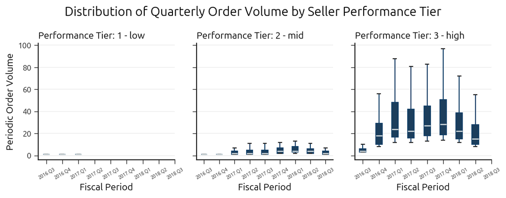

```python
plt.style.use(STYLE_PATH)
plt.rcParams.update({
    'xtick.labelsize': 6
})

col_order = ["1 - low", "2 - mid", "3 - high"]
fig, axes = plt.subplots(1, 3, figsize = (9, 3.5), sharey = True)

for i, rank in enumerate(col_order):
    data_subset = df_q111[df_q111["performance_tier"] == rank]
    sns.boxplot(data = data_subset, x = "quarterly", y = "order_volume", ax = axes[i],
                fill = True, showfliers = False, width = 0.4, linewidth = 1.25, color = full_palette[0],
                whiskerprops = {"color": full_palette[0]}, boxprops = {"edgecolor": full_palette[0]}, medianprops = {"color": "#CFD8DC", "linewidth": 1.5})
    axes[i].set_title(f"Performance Tier: {rank}", fontsize = 12)
    axes[i].set_xlabel("Fiscal Period")
    axes[i].tick_params(axis = 'x', rotation = 30)
    if i == 0:
        axes[i].set_ylabel("Periodic Order Volume")
    else:
        axes[i].set_ylabel("")
    axes[i].set_xticks(range(len(df_q111['quarterly'].unique())))
    axes[i].set_xticklabels(df_q111['quarterly'].unique())

plt.suptitle(f"Distribution of Quarterly Order Volume by Seller Performance Tier")

plt.tight_layout()

file_name = 'Fig1.1.1 Distribution of Quarterly Order Volume by Seller Performance Tier.png'
save_path = os.path.join(FIGURES_PATH, file_name)
plt.savefig(save_path)
plt.show()
```

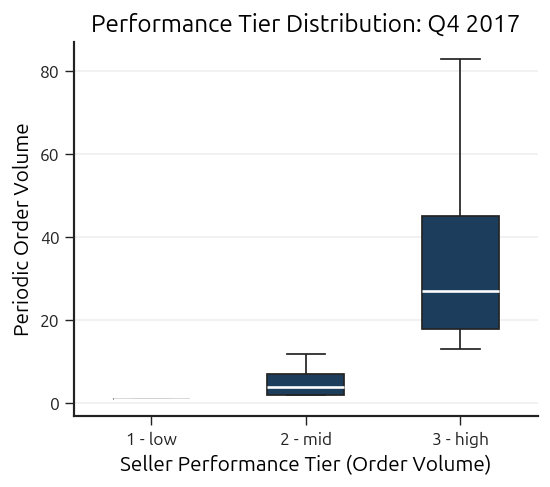

```python
selected_period = "2017.Q4"
year_quarter = selected_period.split('.')

df_q111_s = df_q111[df_q111["quarterly"] == selected_period]

plt.style.use(STYLE_PATH)
plt.rcParams.update({
    'figure.figsize': (4.5,4)
})

sns.boxplot(data = df_q111_s, x = "performance_tier", y = "order_volume",
            order = ["1 - low", "2 - mid", "3 - high"],
            fill = True, showfliers = False, width = .5, medianprops = {"color": "w", "linewidth": 1.5})

plt.xlabel("Seller Performance Tier (Order Volume)")
plt.ylabel("Periodic Order Volume")
plt.title(f"Performance Tier Distribution: {year_quarter[1]} {year_quarter[0]}", loc = 'center')

plt.tight_layout()

file_name = 'Fig1.1.2 Performance Tier Distribution.png'
save_path = os.path.join(FIGURES_PATH, file_name)
plt.savefig(save_path)
plt.show()
```

**Figure 1.1.1 & 1.1.2 - Observations**

- The distribution in **Mid Tier** shows a low variance, indicating a large group of consistent merchants who maintain a steady but limited throughput (< 10 orders per quarter).
- The **High Tier** exhibits significant spread and seasonality. The median order volume for top merchants peaked in Q4 2017 before showing a downward trend in subsequent quarters. This suggests that while the top 25% of merchants handle the bulk of the platform's traffic, their individual scale varies substantially, with some 'leaders' processing over 80 orders while others barely reaching 30.
- When isolating the peak performance period in **Q4 2017**, the gap between Tiers becomes even more visible. While the Mid Tier median indicates a rate of nearly 5 orders per quarter, the High Tier's median jumps to nearly 30, with outliers reaching over 80.
- A practically non-existent **Low Tier** indicates no clear pattern of emergence for very small merchants.

**Business Insights**

The disparity in volume between the Mid and High Tiers highlights a **"long tail" marketplace structure**, where a small fraction of merchants (Tier 3) is responsible for a disproportionately high volume of the platform's operational load. This suggests that the platform’s success is **heavily dependent on a small group of leaders** rather than a broad distribution of small merchants. Transitioning from a mid to a high tier may be unreachable for smaller merchants. Additionally, the absence of Low Tier sellers highlights the lack of a clear entry-level path for growth.

```python
%%sql
--DROP VIEW IF EXISTS analytics.int_market_leaders;
CREATE OR REPLACE VIEW analytics.int_market_leaders AS
SELECT
    seller_sk,
    'leader_0' || (ROW_NUMBER() OVER (ORDER BY COUNT(DISTINCT order_sk) DESC))::TEXT AS leader_label
FROM
    fact_order_items
GROUP BY
    seller_sk
ORDER BY
    COUNT(DISTINCT order_sk) DESC
LIMIT 3;
```

**SQL Logic**

View: *int_market_leaders*

This internal view identifies and labels the top three sellers (Market Leaders) by transaction volume:

- Aggregation: I calculated the **COUNT(DISTINCT)** of order keys per seller to determine the absolute total transaction volume for each merchant;
- Ranking: I used the **ROW_NUMBER()** window function ordered by the transaction count in **DESC** order to establish a volume-based hierarchy;
- Labeling: I applied string concatenation to the ranking index to generate standardized *leader_0** identifiers, facilitating anonymized reporting;
- Filtering: I implemented a **LIMIT** clause to isolate only the three highest-performing sellers from the entire merchant population.

This logic ensures a high-integrity identification of market leaders by using unique order counts rather than item counts. The resulting labels provide a stable joining key for all subsequent comparative and longitudinal analyses.

```python
%%sql
--DROP VIEW IF EXISTS analytics.rpt_q1_leaders_market_share;
CREATE OR REPLACE VIEW analytics.rpt_q1_leaders_market_share AS
WITH seller_periodic_volume AS (
    SELECT
        foi.seller_sk,
        COUNT(DISTINCT o.order_sk) AS order_volume,
        (EXTRACT(YEAR FROM order_purchase_t)::TEXT || '.Q' || EXTRACT(quarter FROM order_purchase_t)::TEXT) AS quarterly
    FROM
        fact_order_items foi
        LEFT JOIN dim_orders o ON foi.order_sk = o.order_sk
    GROUP BY
        foi.seller_sk,
        (EXTRACT(YEAR FROM order_purchase_t)::TEXT || '.Q' || EXTRACT(quarter FROM order_purchase_t)::TEXT)
), market_segmented_volume AS (
    SELECT
        spv.quarterly,
        COALESCE(ml.leader_label, 'residual') AS market_segment,
        spv.order_volume
    FROM
        seller_periodic_volume spv
        LEFT JOIN analytics.int_market_leaders ml ON spv.seller_sk = ml.seller_sk
)
SELECT
    quarterly,
    market_segment,
    PERCENTILE_CONT(0.5) WITHIN GROUP (ORDER BY order_volume) AS median_segment_volume
FROM
    market_segmented_volume
GROUP BY
    quarterly,
    market_segment
ORDER BY
    quarterly ASC,
    CASE WHEN market_segment = 'residual' THEN 1 ELSE 0 END ASC,
    market_segment ASC;
```

```python
df_q112 = pd.read_sql("SELECT * FROM analytics.rpt_q1_leaders_market_share;", engine)
```

**SQL Logic**

View: *rpt_q1_leaders_market_share*

This view calculates the median transaction volume per fiscal quarter for identified market leaders:

- Temporal Grain: A standard YYYY.Q fiscal quarter identifier was created following the methodological framework defined in the previous view;
- Aggregation: I calculated the **COUNT(DISTINCT)** of order keys per seller and quarter to determine the unique transaction volume per period;
- Market Segmentation: I used the **COALESCE()** function to map specific seller keys to their leader labels, grouping all non-leader sellers into a *residual* category;
- Metrics: I used **PERCENTILE_CONT(0.5)** to derive the median volume for each segment, ensuring the benchmark is not affected by extreme outliers within the leader or Residual segment.

This logic provides a robust comparative framework by using median values instead of averages, accurately reflecting the typical output of a market leader versus the residual. Utilizing a dynamic temporal grain ensures that the baseline shifts naturally with the platform's quarterly growth.

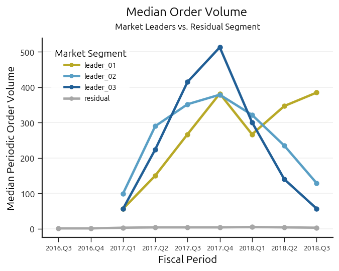

```python
plt.style.use(STYLE_PATH)
plt.rcParams.update({
    'figure.figsize': (5.5,4.5),
    'xtick.labelsize': 8
})

custom_palette = [full_palette[3],full_palette[2],full_palette[1],"#A7A7A7"]

ax = sns.pointplot(data = df_q112, x = "quarterly", y = "median_segment_volume", hue = "market_segment",
                   hue_order = ["leader_01", "leader_02", "leader_03", "residual"], palette = custom_palette, markers = "o", markersize = 4, linestyles = "-")

plt.legend(title = "Market Segment", loc = 'upper left', bbox_to_anchor = (0.02, 0.98), fontsize = 'small')
ax.set_xticks(range(len(df_q112['quarterly'].unique())))
ax.set_xticklabels(df_q112['quarterly'].unique())

plt.xlabel("Fiscal Period")
plt.ylabel("Median Periodic Order Volume")
plt.suptitle("Median Order Volume", fontsize = 14, fontweight = 'bold', y = 0.95, x = 0.55)
plt.title("Market Leaders vs. Residual Segment", fontsize = 10, loc = 'center', pad = 10)

plt.tight_layout()

file_name = 'Fig1.1.3 Median Order Volume - Market Leaders vs. Residual Segment.png'
save_path = os.path.join(FIGURES_PATH, file_name)
plt.savefig(save_path)
plt.show()
```

**Figure 1.1.3 - Observations**

The line chart reveals a clear operational divergence between the platform's **Leaders** (top three sellers in order volume) and the **Residual** segment (general merchant population, median order volume of all other sellers). While the Residual segment remains flat — rarely exceeding 5 orders per quarter — the Leaders exhibit high volatility and massive scale.

**Business Insights**

The platform's total GMV (Gross Merchandise Volume) is **heavily concentrated around a few Leaders**. Sharp changes in a Leader's throughput may lead to platform-wide losses that the residual segment cannot easily absorb.

The data suggests two distinct seller types. The Residuals require tools for steady, incremental growth, while the Leaders likely require **logistical support** to manage the high-variance nature of their demand.

> *Note on Methodology: I used the Median rather than the Mean for segment comparisons to account for the heavy right-skew of the seller population. This ensures the baseline accurately reflects the typical merchant's throughput without being distorted by outliers.*

### Q1.2 Seller Distribution across Delivery Delay Tiers

```python
%%sql
--DROP VIEW IF EXISTS analytics.rpt_q1_seller_delivery_delay_segmentation;
CREATE OR REPLACE VIEW analytics.rpt_q1_seller_delivery_delay_segmentation AS
WITH is_delivery_late AS (
    SELECT
        order_sk,
        CASE WHEN DATE_TRUNC('day', order_estimated_delivery_t) < DATE_TRUNC('day', order_delivered_customer_t) THEN 1 ELSE 0 END AS is_late
    FROM dim_orders
    WHERE DATE_TRUNC('day', order_estimated_delivery_t) IS NOT NULL AND DATE_TRUNC('day', order_delivered_customer_t) IS NOT NULL
), seller_volume_join AS (
    SELECT DISTINCT
        foi.seller_sk,
        idl.order_sk,
        idl.is_late
    FROM
        is_delivery_late idl
        LEFT JOIN fact_order_items foi ON foi.order_sk = idl.order_sk
), seller_volume AS (
    SELECT
        seller_sk,
        COUNT(order_sk) AS order_volume,
        SUM(is_late) AS total_volume_late_deliv
    FROM seller_volume_join
    GROUP BY seller_sk
), seller_late_delivery_rate AS (
    SELECT
        seller_sk,
        order_volume,
        ROUND(total_volume_late_deliv::NUMERIC / order_volume, 3) * 100 AS late_delivery_rate
    FROM
        seller_volume
), market_ldr_thresholds AS(
    SELECT DISTINCT
        PERCENTILE_CONT(0.25) WITHIN GROUP (ORDER BY late_delivery_rate) AS vol_p25,
        PERCENTILE_CONT(0.75) WITHIN GROUP (ORDER BY late_delivery_rate) AS vol_p75
    FROM seller_late_delivery_rate
)
SELECT
    sldr.seller_sk AS seller_id,
    sldr.late_delivery_rate,
    mldr.vol_p25,
    mldr.vol_p75,
    CASE WHEN sldr.late_delivery_rate > mldr.vol_p75 THEN '3 - high risk'
         WHEN sldr.late_delivery_rate <= mldr.vol_p25 THEN '1 - low risk'
         ELSE '2 - medium risk' END AS reliability_tier
FROM
    seller_late_delivery_rate sldr,
    market_ldr_thresholds mldr
ORDER BY sldr.seller_sk;
```

```python
df_q121 = pd.read_sql("SELECT * FROM analytics.rpt_q1_seller_delivery_delay_segmentation;", engine)
```

**SQL Logic**

View: *rpt_q1_seller_delivery_delay_segmentation*

This view classifies sellers into reliability tiers based on their historical Late Delivery Rates (LDR) relative to market-wide performance thresholds:

- Temporal Grain: I used the **DATE_TRUNC()** function to normalize timestamps to a daily grain, ensuring that delivery delays are calculated based on calendar days rather than specific hours;
- Flag Identification: I implemented a **CASE WHEN** logic to flag orders where the actual delivery date exceeded the estimated delivery date;
- Aggregation: I calculated the total **COUNT()** of orders and the **SUM()** of late flags per seller to establish the basis for rate calculations. Then I used numeric casting to derive a percentage-based *late_delivery_rate* for each merchant;
- Dynamic Thresholding: I utilized **PERCENTILE_CONT()** within a CTE to identify the 25th and 75th percentiles of LDR across the entire seller population;
- Tiered Classification: I used **CASE WHEN** syntax to assign risk profiles based on the calculated market thresholds:
  - Tier 3 (*3 - high risk*): Sellers with LDR above the 75th percentile;
  - Tier 2 (*2 - medium risk*): Sellers within the interquartile range (25th to 75th percentile);
  - Tier 1 (*1 - low risk*): Sellers with LDR at or below the 25th percentile.

This logic provides a statistically grounded method for auditing logistics quality, as it benchmarks individual seller reliable delivery failure rates against global market standards.

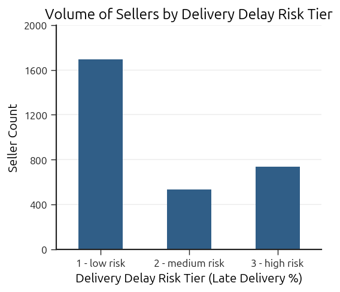

```python
plt.style.use(STYLE_PATH)
plt.rcParams.update({
    'figure.figsize': (4.5,4)
})

sns.countplot(data = df_q121, x = "reliability_tier",
            order = ["1 - low risk", "2 - medium risk", "3 - high risk"],
            fill = True, width = .5, color = full_palette[1])

plt.yticks([0,400,800,1200,1600,2000], ['0','400','800','1200','1600','2000'])

plt.xlabel("Delivery Delay Risk Tier (Late Delivery %)")
plt.ylabel("Seller Count")
plt.title(f"Volume of Sellers by Delivery Delay Risk Tier", loc = 'center')

plt.tight_layout()

file_name = 'Fig1.2.1 Volume of Sellers by Delivery Delay Risk Tier.png'
save_path = os.path.join(FIGURES_PATH, file_name)
plt.savefig(save_path)
plt.show()
```

**Figure 1.2.1 - Observations**

The bar chart illustrates the distribution of the merchant base across the three defined risk tiers. A significant majority of sellers (over 1,600) maintain a Late Delivery Rate within the bottom 25th percentile of the market. Classified within the Low Risk category, they showcase a high level of operational discipline. The distribution shows a higher concentration at the Low Risk end, with a secondary bump at the High Risk end, rather than a perfect normal distribution. This suggests that sellers often either excel at the logistics or fail to deliver on time.

**Business Insights**

The prevalence of Low Risk sellers suggests that the platform's delivery infrastructure and the logic of estimating delivery time are **well-aligned for the majority of merchants**.

```python
%%sql
--DROP VIEW IF EXISTS analytics.rpt_q1_leaders_market_share_delay_risk;
CREATE OR REPLACE VIEW analytics.rpt_q1_leaders_market_share_delay_risk AS
WITH is_delivery_late AS (
    SELECT
        o.order_sk,
        foi.seller_sk,
        CASE WHEN DATE_TRUNC('day', o.order_estimated_delivery_t) < DATE_TRUNC('day', o.order_delivered_customer_t)
             THEN 1 ELSE 0 END AS is_late
    FROM dim_orders o
    JOIN fact_order_items foi ON o.order_sk = foi.order_sk
    WHERE o.order_estimated_delivery_t IS NOT NULL
      AND o.order_delivered_customer_t IS NOT NULL
), seller_late_delivery_sum AS (
    SELECT
        COALESCE(ml.leader_label, 'residual') AS market_segment,
        COUNT(DISTINCT idl.order_sk) AS order_volume,
        SUM(idl.is_late) AS late_deliv_count
    FROM is_delivery_late idl
    LEFT JOIN analytics.int_market_leaders ml ON idl.seller_sk = ml.seller_sk
    GROUP BY 1
), seller_late_delivery_rate AS (
    SELECT
        market_segment,
        ROUND(late_deliv_count::NUMERIC / order_volume, 3) * 100 AS ldr
    FROM
        seller_late_delivery_sum
), market_ldr_thresholds AS (
    SELECT
        PERCENTILE_CONT(0.25) WITHIN GROUP (ORDER BY ldr) AS q1st,
        PERCENTILE_CONT(0.75) WITHIN GROUP (ORDER BY ldr) AS q3rd
    FROM seller_late_delivery_rate
)
SELECT
    sldr.market_segment,
    sldr.ldr,
    mldr.q1st,
    mldr.q3rd,
    CASE
        WHEN sldr.ldr > mldr.q3rd THEN '3 - high risk'
        WHEN sldr.ldr <= mldr.q1st THEN '1 - low risk'
        ELSE '2 - medium risk'
    END AS delivery_delay_risk
FROM
    seller_late_delivery_rate sldr
CROSS JOIN
    market_ldr_thresholds mldr
ORDER BY
    sldr.market_segment;
```

**SQL Logic**

View: *rpt_q1_leaders_market_share_delay_risk*

This view assesses the logistical reliability of market leaders by benchmarking their Late Delivery Rates (LDR) against the overall performance thresholds of the platform's key segments:

- Temporal Grain: delivery timestamps normalized to a daily grain following the methodological framework defined in the previous view;
- Flag Identification: orders where the actual customer delivery date occurred after the estimated delivery date flaged following the methodological framework defined in the previous view;
- Market Segmentation: created using the intermediate view (*int_market_leaders*) and mapping;
- Aggregation: I calculated the **COUNT(DISTINCT)** of orders and the **SUM()** of late flags per segment to derive a percentage-based *ldr*;
- Dynamic Thresholding: following the methodological framework defined in the previous view;
- Tiered Classification: following the methodological framework defined in the previous view:
  - Tier 3 (*3 - high risk*): Segments with LDR above the 75th percentile;
  - Tier 2 (*2 - medium risk*): Segments within the interquartile range (25th to 75th percentile);
  - Tier 1 (*1 - low risk*): Segments with LDR at or below the 25th percentile.

This logic provides a comparative audit of top-tier sellers, revealing whether market dominance correlates with logistical stability. By utilizing relative thresholds, the view identifies if leaders are maintaining superior service levels compared to the general market baseline.

```python
df_q122 = pd.read_sql("SELECT * FROM analytics.rpt_q1_leaders_market_share_delay_risk;", engine)
df_to_save = df_q122.rename(columns={'market_segment': 'Market Segment','ldr': 'Late Delivery Rate','q1st': '1st Q','q3rd': '3rd Q','delivery_delay_risk': 'Delivery Delay Risk'})
df_to_save[['Late Delivery Rate', '1st Q', '3rd Q']] = df_to_save[['Late Delivery Rate', '1st Q', '3rd Q']].map(lambda x: f"{x:.1f}%")

display(df_to_save)

file_name = 'Tab1.2.2 LDR and Delivery Delay Risk - Market Leaders vs. Residual Segment.png'
save_path = os.path.join(FIGURES_PATH, file_name)
save_df_as_png(df_to_save, save_path)
```

|  | Market Segment | Late Delivery Rate | 1st Q | 3rd Q | Delivery Delay Risk |
| --- | --- | --- | --- | --- | --- |
| 0 | leader_01 | 5.6% | 5.5% | 8.3% | 2 - medium risk |
| 1 | leader_02 | 10.7% | 5.5% | 8.3% | 3 - high risk |
| 2 | leader_03 | 5.3% | 5.5% | 8.3% | 1 - low risk |
| 3 | residual | 7.5% | 5.5% | 8.3% | 2 - medium risk |

**Table 1.2.2 - Observations**

**Business Insights**

While Leader 03 provides a blueprint for scalable fulfillment, the platform's reliability reputation is disproportionately vulnerable to Leader 02. Because this seller handles a massive volume of orders (as seen in *Figure 1.1.3*), their 10.7% failure rate generates a significantly higher absolute number of dissatisfied customers compared to hundreds of smaller sellers combined. Leader 02 requires **immediate operational intervention** to protect platform-wide customer retention.

### Q1.3 Trailing 6 Months Late Delivery Rate

```python
%%sql
--DROP VIEW IF EXISTS analytics.int_leaders_late_delivery_count;
CREATE OR REPLACE VIEW analytics.int_leaders_late_delivery_count AS
WITH order_volume_segmentation AS (
    SELECT DISTINCT
        foi.order_sk,
        COALESCE(ml.leader_label, 'residual') AS market_segment
    FROM
        fact_order_items foi
        LEFT JOIN analytics.int_market_leaders ml ON foi.seller_sk = ml.seller_sk
)
SELECT
    ovs.market_segment,
    DATE_TRUNC('month', o.order_estimated_delivery_t)::date AS monthly,
    COUNT(DISTINCT o.order_sk) AS order_volume,
    SUM(CASE WHEN o.order_delivered_customer_t > o.order_estimated_delivery_t THEN 1 ELSE 0 END) AS late_deliv_count
FROM
    dim_orders o
    JOIN order_volume_segmentation ovs ON ovs.order_sk = o.order_sk
WHERE
    o.order_estimated_delivery_t IS NOT NULL
    AND o.order_delivered_customer_t IS NOT NULL
GROUP BY
    1, 2;
```

**SQL Logic**

View: *int_leaders_late_delivery_count*

This internal view aggregates monthly transaction volumes and late delivery occurrences to facilitate a longitudinal analysis of logistical failures across different market segments:

- Market Segmentation: I used the **COALESCE()** function to map orders to specific leader labels while grouping all remaining volume into a *residual* baseline;
- Temporal Grain: I utilized the **DATE_TRUNC()** function cast to a *::date* type to normalize all order records into a standardized monthly grain;
- Flag Identification: I implemented a **CASE WHEN** logic within a **SUM()** function to count instances where the actual delivery timestamp exceeded the estimated delivery date;
- Aggregation: I calculated the **COUNT(DISTINCT)** of order keys per segment and month to determine the unique transaction volume per period.

This logic provides a granular temporal dataset that allows for the detection of seasonal trends in delivery performance. By separating market leaders from the residual segment, it identifies whether logistics degradation is a platform-wide issue or isolated to high-volume sellers.

```python
%%sql
--DROP VIEW IF EXISTS analytics.rpt_q1_leaders_l6m_late_delivery_rate;
CREATE OR REPLACE VIEW analytics.rpt_q1_leaders_l6m_late_delivery_rate AS
SELECT
    market_segment,
    monthly,
    order_volume,
    late_deliv_count,
    ROUND(late_deliv_count::numeric / order_volume, 3) AS monthly_late_rate,
    ROUND(SUM(late_deliv_count) OVER (
        PARTITION BY market_segment
        ORDER BY monthly
        RANGE BETWEEN INTERVAL '5 months' PRECEDING AND CURRENT ROW)::numeric
        /
        SUM(order_volume) OVER (
        PARTITION BY market_segment
        ORDER BY monthly
        RANGE BETWEEN INTERVAL '5 months' PRECEDING AND CURRENT ROW), 3) AS l6m_late_rate
FROM analytics.int_leaders_late_delivery_count;
```

```python
df_q131 = pd.read_sql("SELECT * FROM analytics.rpt_q1_leaders_l6m_late_delivery_rate;", engine)
df_q131['monthly'] = pd.to_datetime(df_q131['monthly']).dt.strftime('%Y-%m')
df_q131 = df_q131.sort_values('monthly')
```

**SQL Logic**

View: *rpt_q1_leaders_l6m_late_delivery_rate*

This view calculates monthly and rolling six-month late delivery rates to identify long-term trends and short-term fluctuations in logistical performance across market segments:

- Metrics: I used numeric casting and the division of *late_deliv_count* by *order_volume* to derive the *monthly_late_rate*;
- Aggregation: I implemented the **SUM()** window function to compute cumulative totals for both late deliveries and order volumes within specific partitions;
- Temporal Windowing: I utilized the **RANGE BETWEEN** clause with an **INTERVAL** of 5 months preceding the current row to establish a rolling six-month observation period;
- Smoothing: I calculated the *l6m_late_rate* by dividing the rolling sum of late deliveries by the rolling sum of total orders, effectively smoothing out monthly volatility.

This logic provides a sophisticated dual-perspective metric that balances immediate operational snapshots with historical performance trends. By using a rolling six-month average, the view filters out temporary seasonal noise to reveal the true trajectory of a segment's logistical reliability.

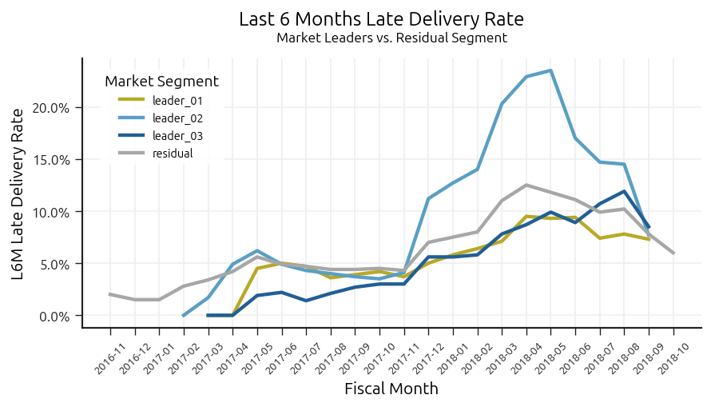

```python
first_quarter = df_q131["monthly"].min()
df_q131_s = df_q131[df_q131["monthly"] != first_quarter]

plt.style.use(STYLE_PATH)
custom_palette = [full_palette[3],full_palette[2],full_palette[1],"#A7A7A7"]
plt.rcParams.update({
    'figure.figsize': (8,3.5),
    'xtick.labelsize': 8})

ax = sns.lineplot(data = df_q131_s, x = 'monthly', y = 'l6m_late_rate', hue = 'market_segment',
    hue_order = ["leader_01", "leader_02", "leader_03", "residual"], palette = custom_palette, linewidth = 2.5)

plt.legend(title = "Market Segment", loc = 'upper left', bbox_to_anchor=(0.02, 0.98), fontsize = 'small')
ax.yaxis.set_major_formatter(mtick.PercentFormatter(1))
unique_months = df_q131_s['monthly'].unique()
ax.set_xticks(range(len(unique_months)))
ax.set_xticklabels(unique_months, rotation = 45)

plt.xlabel("Fiscal Month")
plt.ylabel("L6M Late Delivery Rate")
plt.suptitle("Last 6 Months Late Delivery Rate", fontsize = 14, fontweight = 'bold', y = 1.02)
plt.title("Market Leaders vs. Residual Segment", fontsize = 10, loc = 'center', pad = 12)

file_name = 'Fig1.3.1 L6M LDR - Market Leaders vs. Residual Segment.png'
save_path = os.path.join(FIGURES_PATH, file_name)
plt.savefig(save_path)
plt.show()
```

**Figure 1.3.1 - Observations**

The time-series analysis of the Trailing 6-Month (L6M) Late Delivery Rate provides a smoothed view of operational health, allowing us to distinguish between temporary logistical difficulties and systemic decline.

**Business Insights**

By comparing Leaders to the Residual baseline, we can identify that the logistics of Leader 01 and Leader 03 are following the market trend, whereas Leader 02 represents an **isolated operational risk** for the platform.

This analysis reinforces the danger of high-concentration marketplaces. The volatility of a single merchant (Leader 02) can disproportionately skew the platform’s overall fulfillment metrics, highlighting the need to **diversify the leader base** or enforce **stricter Service Level Agreements (SLAs)** for high-volume accounts.

### Q1.4 Dynamic Rank of Seller Delivery Delay Risk

```python
%%sql
--DROP VIEW IF EXISTS analytics.rpt_q1_leaders_monthly_ldr_segmentation;
CREATE OR REPLACE VIEW analytics.rpt_q1_leaders_monthly_ldr_segmentation AS
SELECT
    market_segment,
    monthly,
    ROUND(late_deliv_count::numeric / NULLIF(order_volume, 0), 3) AS monthly_late_rate,
    RANK() OVER (PARTITION BY monthly ORDER BY (late_deliv_count::numeric / NULLIF(order_volume, 0)) DESC) AS delay_risk_rank
FROM analytics.int_leaders_late_delivery_count
WHERE order_volume > 0;
```

```python
df_q141 = pd.read_sql("SELECT * FROM analytics.rpt_q1_leaders_monthly_ldr_segmentation;", engine)
df_q141['monthly'] = pd.to_datetime(df_q141['monthly']).dt.strftime('%Y-%m')
df_q141 = df_q141.sort_values('monthly')
```

**SQL Logic**

View: *rpt_q1_leaders_monthly_ldr_segmentation*

This view establishes a relative risk hierarchy by ranking market segments according to their monthly Late Delivery Rates (LDR) to identify the most underperforming clusters in any given period:

- Metrics: *monthly_late_rate* was calculated following the logic from the previous view. I implemented the **NULLIF()** function to account for months with zero recorded orders;
- Ranking: I used the **RANK()** window function partitioned by *monthly* and ordered by the failure rate in **DESC** order:
  - *Rank 1*: Highest relative delay risk within the given month,
  - *Rank 2 & 3*: Intermediate relative risk positions,
  - *Rank 4*: Lowest relative delay risk compared to other segments;
- Filtering: I applied a **WHERE** clause to exclude records with zero *order_volume*, ensuring the statistical validity of the resulting risk hierarchy.

This logic enables a period-over-period competitive audit, highlighting which segments are currently driving the platform's delivery delays. By ranking segments within each month, the view identifies if specific leaders are consistently outperforming or lagging behind the market baseline regardless of seasonal volume shifts.

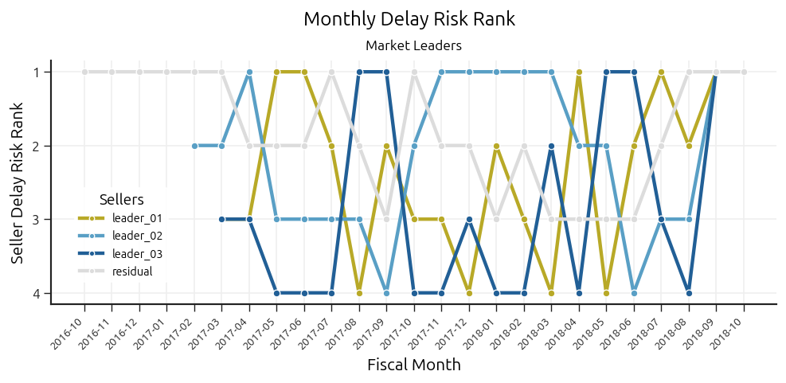

```python
plt.style.use(STYLE_PATH)
plt.rcParams.update({
    'figure.figsize': (8,4),
    'xtick.labelsize': 8})

custom_palette = [full_palette[3],full_palette[2],full_palette[1],"#DCDCDC"]

ax = sns.lineplot(data = df_q141, x = 'monthly', y = 'delay_risk_rank', hue = 'market_segment',
    hue_order = ["leader_01", "leader_02", "leader_03", "residual"], palette = custom_palette, marker = 'o', linewidth = 2.5)

plt.legend(title = "Sellers", loc = 'upper left', bbox_to_anchor = (0.025, 0.5), fontsize = 'small')
plt.yticks([1,2,3,4], ['1','2','3','4'])
ax.invert_yaxis()
unique_months = df_q141['monthly'].unique()
ax.set_xticks(unique_months)
ax.set_xticklabels(unique_months, rotation = 45, ha = 'right')

plt.xlabel("Fiscal Month")
plt.ylabel("Seller Delay Risk Rank")
plt.suptitle("Monthly Delay Risk Rank", fontsize = 14, fontweight = 'bold', y = 0.95, x = 0.52)
plt.title("Market Leaders", fontsize = 10, loc = 'center', pad = 8)

plt.tight_layout()

file_name = 'Fig1.4.1 Monthly Delay Risk Rank in Market Leaders.png'
save_path = os.path.join(FIGURES_PATH, file_name)
plt.savefig(save_path)
plt.show()
```

**Figure 1.4.1 - Observations**

This bump chart visualizes the relative performance of the three Market Leaders, with the Residual (market baseline) serving as a fixed reference. By ranking the sellers monthly, we identify the temporal dynamics of who is the "at-risk" merchant within the platform’s high-volume segment.

**Business Insights**

## Q2 Product Category Profitability & Price Sensitivity

This section shifts the focus to the marketplace’s branches, identifying the high-yield categories and pricing structures that drive overall platform gross merchandise value:

- **Q2.1** maps the product catalog to identify the primary revenue drivers and evaluates the concentration of market share among top categories;
- **Q2.2** intersects unit volume with median pricing to isolate high-yield segments and leading categories;
- **Q2.3** applies Price Tiering to reveal the platform’s dependency on luxury versus mass-market goods;
- **Q2.4** utilizes regression to determine the revenue-to-volume efficiency of each category.

### Q2.1 Category Portfolio: Revenue, Volume and Price

```python
%%sql
--DROP VIEW IF EXISTS analytics.rpt_q2_product_category_performance;
CREATE OR REPLACE VIEW analytics.rpt_q2_product_category_performance AS
WITH foi_category AS (
    SELECT
        foi.price,
        COALESCE(lpc.prod_cat_eng, p.product_category, 'unknown') AS category
    FROM
        fact_order_items foi
        LEFT JOIN dim_products p ON p.product_sk = foi.product_sk
        LEFT JOIN lookup_prod_cat lpc ON lpc.prod_cat = p.product_category
    WHERE foi.price > 0
), grouped_metrics AS (
    SELECT
        category AS product_category,
        SUM(price) AS total_revenue,
        PERCENTILE_CONT(.5) WITHIN GROUP (ORDER BY price) AS median_price,
        COUNT(*) AS total_units
    FROM foi_category
    GROUP BY product_category
)
SELECT
    *,
    ROUND(total_revenue * 1.0 / SUM(total_revenue) OVER(), 4) AS perc_in_revenue
FROM grouped_metrics;
```

```python
df_q211 = pd.read_sql("SELECT * FROM analytics.rpt_q2_product_category_performance;", engine)
```

**SQL Logic**

View: *rpt_q2_product_category_performance*

This view evaluates the commercial health of various product segments by aggregating total revenue, unit volume, and median pricing to identify high-yield market categories:

- Mapping: I used the **COALESCE()** function to translate technical category keys into English labels while providing an *unknown* fallback for missing metadata;
- Filtering: I applied a **WHERE** clause to exclude transactions with zero or negative price values, ensuring the integrity of the financial metrics;
- Aggregation: I calculated the **SUM()** of prices to determine *total_revenue* and the **COUNT(*)** of records to establish per category;
- Metrics: I implemented **PERCENTILE_CONT(0.5)** within each category to derive the *median_price*, providing a robust benchmark against price outliers; Then I utilized a window-based **SUM()** to calculate the *perc_in_revenue*, expressing each category's contribution as a percentage of the total platform GMV.

This logic provides a multidimensional view of the product catalog, allowing for the immediate identification of "star" categories that drive significant revenue. By combining median pricing with revenue share, the view highlights segments where the platform has the strongest market positioning.

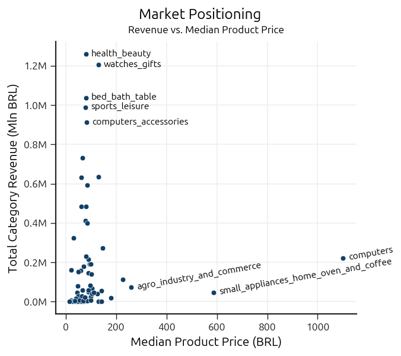

```python
plt.style.use(STYLE_PATH)

fig, ax = plt.subplots(figsize = (5.5, 5))
top_5rev = df_q211.nlargest(5, 'total_revenue')
top_3pri = df_q211.nlargest(3, 'median_price')

ax = sns.scatterplot(data = df_q211, x = 'median_price', y = 'total_revenue', color = full_palette[0], s = 25, ax = ax)

for i, row in top_5rev.iterrows():
    ax.annotate(
        row['product_category'],
        xy = (row['median_price'], row['total_revenue']),
        xytext = (5, -2),
        textcoords = 'offset points',
        fontsize = 9)


for i, row in top_3pri.iterrows():
    ax.annotate(
    row['product_category'],
    xy = (row['median_price'], row['total_revenue']),
    xytext = (5, -2),
    textcoords = 'offset points',
    fontsize = 9,
    rotation = 10)

ax.yaxis.set_major_formatter(mtick.FuncFormatter(lambda x, pos: f'{x*1e-6:.1f}M'))

plt.xlabel("Median Product Price (BRL)")
plt.ylabel("Total Category Revenue (Mln BRL)")
plt.suptitle("Market Positioning", fontsize = 14, fontweight = 'bold', y = 0.95, x = 0.5)
plt.title("Revenue vs. Median Product Price", fontsize = 10, loc = 'center', pad = 8)

plt.tight_layout()

file_name = 'Fig2.1.1 Revenue vs. Median Product Price.png'
save_path = os.path.join(FIGURES_PATH, file_name)
plt.savefig(save_path)
plt.show()
```

**Figure 2.1.1 - Observations**

The scatter plot visualizes the strategic landscape of the platform’s product categories by intersecting financial volume with consumer price points. The distribution reveals a high concentration of activity in the low-to-mid price range (under 200 BRL / ~35 USD), while distinct outliers define the platform's market personality:

- Categories such as Health_Beauty, Watches_Gifts, and Bed_Bath_Table dominate the total revenue as **primary GMV drivers** maintain median prices between 80 BRL and 150 BRL (~15–25 USD);
- Categories like Computers, Small_Appliances_Home_Oven_Coffee, and Agro_Industry_and_Commerce are positioned by their higher median prices: exceeding 600 BRL (~115 USD) and reaching over 1,000 BRL (~185 USD) for computers;
- The dense cluster at the bottom-left indicates a high number of categories with low median prices (under 100 BRL / ~20 USD) and modest total revenue, representing a **highly competitive long-tail** of products.

**Business Insights**

The "verticality" of high-revenue categories at relatively low price points suggests that the platform’s current growth is driven by high-frequency, low-to-mid value transactions. This indicates a consumer base that is **highly price-sensitive** and favors essential or lifestyle goods over luxury electronics. Relying on Health_Beauty and Watches_Gifts for the bulk of revenue makes the platform **vulnerable** to shifts in those specific markets.

The Computers category represents a significant outlier. Its high median price combined with relatively low total revenue compared to Health_Beauty suggests a **potential for targeted growth**. Increasing the transaction volume in these categories could disproportionately boost platform GMV without requiring a massive increase in the number of orders.

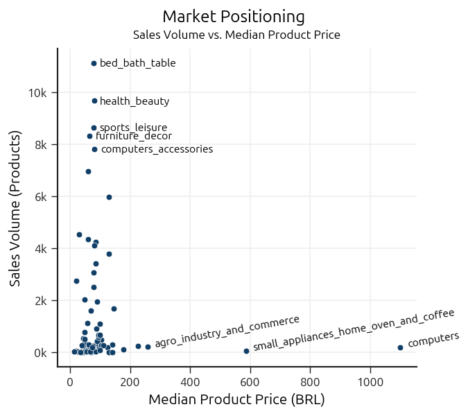

```python
plt.style.use(STYLE_PATH)
fig, ax = plt.subplots(figsize=(5.5, 5))

top_5cou = df_q211.nlargest(5, 'total_units')
top_3pri = df_q211.nlargest(3, 'median_price')

ax = sns.scatterplot(data = df_q211, x = 'median_price', y = 'total_units',
                color = full_palette[0], s = 25, ax = ax)

for i, row in top_5cou.iterrows():
    ax.annotate(
        row['product_category'],
        xy = (row['median_price'], row['total_units']),
        xytext = (5, -3),
        textcoords = 'offset points',
        fontsize = 9
        )

for i, row in top_3pri.iterrows():
    ax.annotate(
        row['product_category'],
        xy = (row['median_price'], row['total_units']),
        xytext = (5, 0),
        textcoords = 'offset points',
        fontsize = 9,
        rotation = 10
        )

ax.yaxis.set_major_formatter(mtick.FuncFormatter(lambda x, pos: f'{x*1e-3:.0f}k'))

plt.xlabel("Median Product Price (BRL)")
plt.ylabel("Sales Volume (Products)")
plt.suptitle("Market Positioning", fontsize = 14, fontweight = 'bold', y = 0.95, x = 0.5)
plt.title("Sales Volume vs. Median Product Price", fontsize = 10, loc = 'center', pad = 8)

plt.tight_layout()

file_name = 'Fig2.1.2 Sales Volume vs. Median Product Price.png'
save_path = os.path.join(FIGURES_PATH, file_name)
plt.savefig(save_path)
plt.show()
```

**Figure 2.1.2 - Observations**

By shifting the dependent variable from revenue to Sales Volume (Total Units), the analysis transitions from financial impact to consumer demand patterns:

- Categories such as Bed_Bath_Table, Health_Beauty, and Sports_Leisure demonstrate the highest sales volume, peaking between 7k and 11k units. These are the platform's "anchors," characterized by high turnover and a relatively low entry price point;
- The plot exhibits a classic inverse relationship - as the Median Product Price increases, the sales volume drops exponentially. Almost all high-volume activity is compressed within the 0 - 200 BRL (~35 USD) range;
- The same outliers identified in the revenue analysis (Computers, Small_Appliances_Home_Oven_Coffee) reappear as low-frequency purchases that contribute to GMV primarily through price rather than quantity.

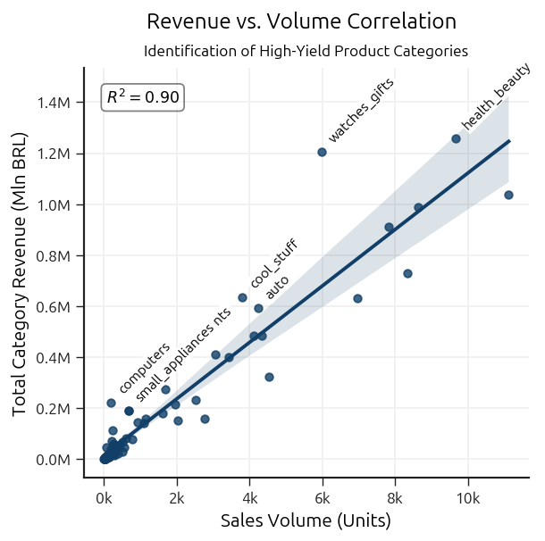

```python
plt.style.use(STYLE_PATH)

fig, ax = plt.subplots(figsize=(5, 5))

pl = sns.regplot(data = df_q211, x = 'total_units', y = 'total_revenue',
                     color = full_palette[0], ax = ax);

slope, intercept, r_val, p_val, std_err = stats.linregress(
                        df_q211['total_units'], df_q211['total_revenue'])

y_pred = intercept + slope * df_q211['total_units']
residuals = df_q211['total_revenue'] - y_pred
see = np.sqrt(np.sum(residuals**2) / (len(df_q211) - 2))
threshold = y_pred + see
outliers = df_q211[df_q211['total_revenue'] > threshold]

r_squared = r_val**2
ax.text(0.05, 0.95, f'$R^2 = {r_squared:.2f}$',
        transform=ax.transAxes, verticalalignment='top', fontsize=10,
        bbox=dict(boxstyle='round', facecolor='white', alpha=0.5))

for i, row in outliers.iterrows():
    ax.annotate(
        row['product_category'], xy = (row['total_units'], row['total_revenue']),
        xytext = (3, 6), textcoords = 'offset points', fontsize = 9, rotation = 45,
        bbox = dict(boxstyle = "square,pad=0.075",fc = "white", ec = "white", lw = 1))

ax.xaxis.set_major_formatter(mtick.StrMethodFormatter('{x:,.0f}'))
ax.yaxis.set_major_formatter(mtick.FuncFormatter(lambda x, pos: f'{x*1e-6:.1f}M'))
ax.xaxis.set_major_formatter(mtick.FuncFormatter(lambda x, pos: f'{x*1e-3:.0f}k'))

plt.xlabel("Sales Volume (Units)")
plt.ylabel("Total Category Revenue (Mln BRL)")
plt.suptitle("Revenue vs. Volume Correlation", fontsize = 14, fontweight = 'bold', y = 0.96, x = 0.55)
plt.title("Identification of High-Yield Product Categories", fontsize = 10, loc = 'center', pad = 8)

plt.tight_layout()

file_name = 'Fig2.1.3 Identification of High-Yield Product Categories.png'
save_path = os.path.join(FIGURES_PATH, file_name)
plt.savefig(save_path)
plt.show()
```

**Figure 2.1.3 - Observations**

**Business Insights**

**Watches_Gifts is the standout performer**. It produces nearly as much revenue as Health_Beauty but requires significantly less logistical throughput (fewer units to pick, pack, and ship). This category represents the ideal balance of high margin and manageable volume. However, not all growth is equal. While Health_Beauty is the largest category, its position closer to the trend line suggests it is to do with its high volume. The platform must ensure that the logistical costs of moving 10k+ units are covered by the margins. Watches_Gifts offers a safer anchor option with roughly half the logistical load.

```python
%%sql
--DROP VIEW IF EXISTS analytics.rpt_q2_top_categories_in_revenue;
CREATE OR REPLACE VIEW analytics.rpt_q2_top_categories_in_revenue AS
WITH category_metrics AS (
    SELECT
        COALESCE(lpc.prod_cat_eng, p.product_category, 'unknown') AS category,
        SUM(foi.price) AS total_revenue,
        COUNT(*) AS units_sold
    FROM fact_order_items foi
    LEFT JOIN dim_products p ON p.product_sk = foi.product_sk
    LEFT JOIN lookup_prod_cat lpc ON lpc.prod_cat = p.product_category
    GROUP BY 1
), category_segmentation AS (
    SELECT
        CASE
            WHEN ROW_NUMBER() OVER (ORDER BY total_revenue DESC) <= 5
            THEN category
            ELSE 'other'
        END AS market_segment,
        total_revenue,
        units_sold
    FROM category_metrics
)
SELECT
    market_segment,
    SUM(units_sold) AS total_units,
    SUM(total_revenue) AS total_revenue,
    SUM(total_revenue) * 1.0 / SUM(SUM(total_revenue)) OVER() AS perc_in_revenue
FROM category_segmentation
GROUP BY market_segment
ORDER BY total_revenue DESC;
```

```python
df_q212 = pd.read_sql("SELECT * FROM analytics.rpt_q2_top_categories_in_revenue;", engine)
```

**SQL Logic**

View: *rpt_q2_top_categories_in_revenue*

This view identifies the five highest-grossing product categories and aggregates all remaining volume into a single baseline to evaluate market concentration and the 80/20 revenue split:

- Mapping: I translated category keys into English following the methodological framework defined in the previous view;
- Aggregation: *total_revenue* and *units_sold* per category were calculated following the methodological framework defined in the previous view;
- Ranking: I utilized the **ROW_NUMBER()** window function ordered by revenue to isolate the top-performing categories;
- Market Segmentation: I implemented a **CASE WHEN** logic within the CTE to label the top five performers by name, while grouping all other categories into a consolidated *other* segment;
- Metrics: *perc_in_revenue* was calculated following the methodological framework defined in the previous view.

This logic simplifies complex marketplace data into a high-level executive summary, highlighting the platform's dependency on its primary revenue drivers. By dynamically grouping the "other" segment, the view maintains focus on the most impactful categories without losing sight of the total market volume.

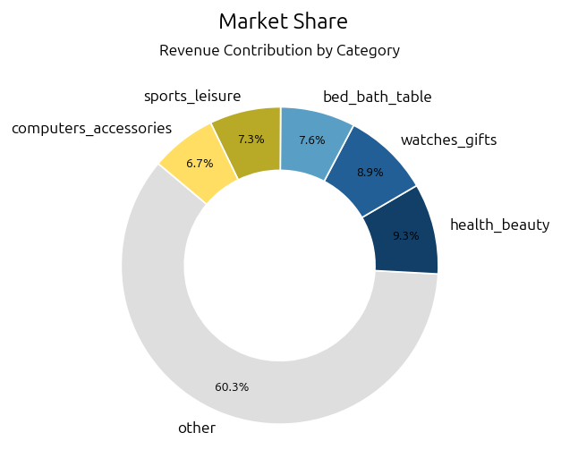

```python
plt.style.use(STYLE_PATH)

custom_palette = ['#DEDEDE', full_palette[0], full_palette[1], full_palette[2], full_palette[3], full_palette[4]]
explode = (0.05, 0, 0, 0, 0, 0)

fig, ax = plt.subplots(figsize = (5, 5))

wedges, texts, autotexts = ax.pie(
    df_q212['perc_in_revenue'],
    labels = df_q212['market_segment'],
    autopct = '%.1f%%',
    startangle = 140,
    pctdistance = 0.82,
    colors = custom_palette,
    wedgeprops = {'width': 0.4, 'edgecolor': 'w'})

plt.setp(autotexts, size = 8, weight = "bold")

plt.suptitle("Market Share", fontsize = 14, fontweight = 'bold', y = 0.9, x = 0.5)
plt.title("Revenue Contribution by Category", fontsize = 10, loc = 'center', pad = 8)

plt.tight_layout()

file_name = 'Fig2.1.4 Revenue Contribution by Category.png'
save_path = os.path.join(FIGURES_PATH, file_name)
plt.savefig(save_path)
plt.show()
```

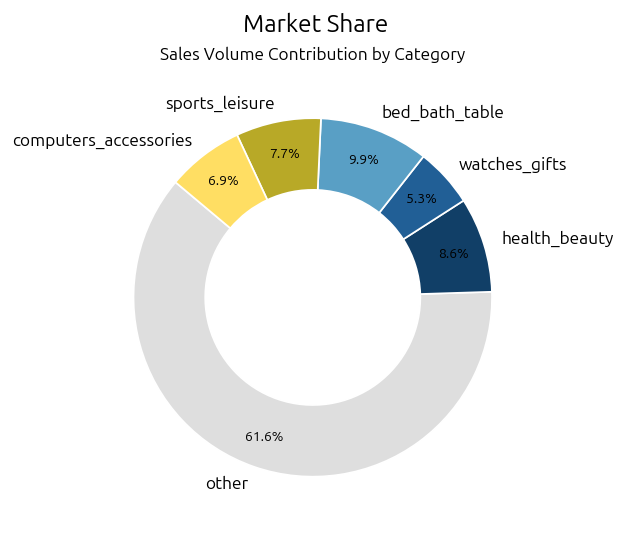

```python
plt.style.use(STYLE_PATH)

custom_palette = ['#DEDEDE', full_palette[0], full_palette[1], full_palette[2], full_palette[3], full_palette[4]]
explode = (0.05, 0, 0, 0, 0, 0)

fig, ax = plt.subplots(figsize = (5, 5))

wedges, texts, autotexts = ax.pie(
    df_q212['total_units'],
    labels = df_q212['market_segment'],
    autopct = '%.1f%%',
    startangle = 140,
    pctdistance = 0.82,
    colors = custom_palette,
    wedgeprops = {'width': 0.4, 'edgecolor': 'w'})

plt.setp(autotexts, size = 8, weight = "bold")

plt.suptitle("Market Share", fontsize = 14, fontweight = 'bold', y = 0.9, x = 0.5)
plt.title("Sales Volume Contribution by Category", fontsize = 10, loc = 'center', pad = 8)

plt.tight_layout()

file_name = 'Fig2.1.5 Sales Volume Contribution by Category.png'
save_path = os.path.join(FIGURES_PATH, file_name)
plt.savefig(save_path)
plt.show()
```

**Figure 2.1.4 & 2.1.5 - Observations**

These donut charts visualize the platform's reliance on its top-performing categories. By segmenting the marketplace into the Top 5 vs. Other, we can assess the structural health of the product portfolio:

- The **Top 5 categories** (Health_Beauty, Watches_Gifts, Bed_Bath_Table, Sports_Leisure, and Computers_and_Accessories) account for approximately 40% of total revenue and nearly 40% of sales volume;
  - Watches_Gifts is a high-yield outlier, contributing 8.9% of revenue despite representing only 5.3% of unit volume (high-margin leader).
  - Bed_Bath_Table is a volume-heavy category (9.9% of units sold) but only 7.6% of revenue (lower price point with higher fulfillment intensity);
- The Other segment comprises over 60 categories but contributes roughly 60% of both revenue and volume - the long-tail offerings provide **a real strength of the platform**.

**Business Insights**

The platform has a **relatively healthy diversification** - no single category controls more than 10% of the market. This decentralization protects the platform from sector-specific shocks. High-volume leaders like Bed_Bath_Table should be prioritized for warehouse optimization and "fast-shipping" programs, as they generate nearly 1 in every 10 packages moved by the platform. Finally, the high revenue-to-volume ratio of Watches_Gifts suggests that marketing spend in this category is highly efficient, yielding more dollars per unit shipped than any other top category.

### Q2.2 Global and Internal Revenue Share by Price Tier

```python
%%sql
--DROP VIEW IF EXISTS analytics.rpt_q2_top_categories_in_revenue_priceband;
CREATE OR REPLACE VIEW analytics.rpt_q2_top_categories_in_revenue_priceband AS
WITH price_thresholds AS (
    SELECT
        PERCENTILE_CONT(0.33) WITHIN GROUP (ORDER BY price) AS price_p33,
        PERCENTILE_CONT(0.66) WITHIN GROUP (ORDER BY price) AS price_p66
    FROM fact_order_items
), base_data AS (
    SELECT
        COALESCE(lpc.prod_cat_eng, p.product_category, 'unknown') AS category,
        foi.price,
        CASE
            WHEN foi.price <= pt.price_p33 THEN '1 - low'
            WHEN foi.price <= pt.price_p66 THEN '2 - medium'
            ELSE '3 - high'
        END AS price_tier
    FROM fact_order_items foi
    CROSS JOIN price_thresholds pt
    LEFT JOIN dim_products p ON p.product_sk = foi.product_sk
    LEFT JOIN lookup_prod_cat lpc ON lpc.prod_cat = p.product_category
),
category_ranking AS (
    SELECT
        category,
        SUM(price) AS cat_revenue,
        ROW_NUMBER() OVER (ORDER BY SUM(price) DESC) as cat_rank
    FROM base_data
    GROUP BY 1
)
SELECT
    CASE
        WHEN r.cat_rank <= 5 THEN b.category
        ELSE 'other'
    END AS market_segment,
    b.price_tier,
    SUM(b.price) AS total_revenue,
    ROUND(SUM(b.price) * 1.0 / SUM(SUM(b.price)) OVER(), 4) AS global_revenue_share,
    ROUND(SUM(b.price) * 1.0 / SUM(SUM(b.price)) OVER(PARTITION BY
        CASE WHEN r.cat_rank <= 5
        THEN b.category
        ELSE 'other' END), 4) AS category_revenue_share
FROM base_data b
JOIN category_ranking r ON b.category = r.category
GROUP BY 1, 2
ORDER BY 1, 2;
```

```python
df_q221 = pd.read_sql("SELECT * FROM analytics.rpt_q2_top_categories_in_revenue_priceband;", engine)
```

**SQL Logic**

View: *rpt_q2_top_categories_in_revenue_priceband*

This view implements a multi-tier pricing segmentation to evaluate revenue distribution across the platform’s product hierarchy, benchmarking the top five categories against the broader market:

- Dynamic Thresholding: I utilized the **PERCENTILE_CONT()** function to establish data-driven price bands at the 33rd (*price_p33*) and 66th (*price_p66*) percentiles;
- Tiered Classification: I implemented a **CASE WHEN** logic to categorize every transaction into one of three price tiers based on the calculated global thresholds:
  - Tier 1 (*1 - low*);
  - Tier 2 (*2 - medium*);
  - Tier 3 (*3 - high*);
- Ranking: I used the **ROW_NUMBER()** window function within a CTE to isolate the five highest-grossing categories by *cat_revenue*;
- Market Segmentation: I applied a **CASE WHEN** logic to label the top five performers while aggregating the remaining categories into an *other* baseline;
- Aggregation: I calculated the **SUM()** of prices to determine *total_revenue* for each segment-tier combination; Metrics: I used window-based **SUM()** functions with different **PARTITION BY** clauses to derive both the *global_revenue_share* and the internal *category_revenue_share*.

This logic reveals the "Price Landscape" of the marketplace by highlighting whether revenue is driven by high-volume low-cost items or high-margin luxury goods. By using percentiles for thresholding, the view ensures that the price tiers remain representative of the actual distribution of the platform's catalog.

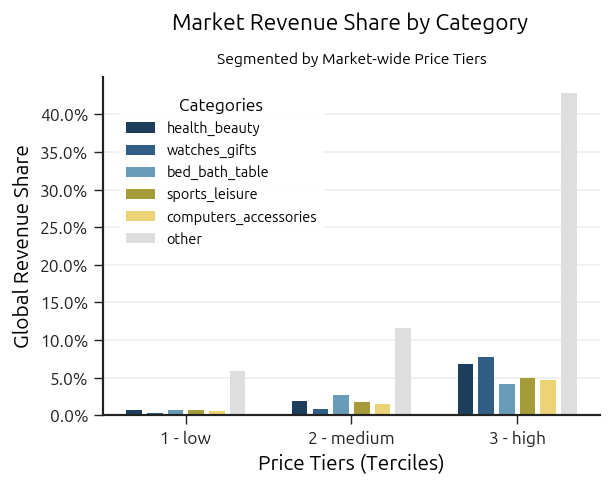

```python
plt.style.use(STYLE_PATH)
plt.rcParams.update({
    'figure.figsize': (5,4),
    'legend.fontsize': 9,
    'legend.title_fontsize': 10
})

custom_palette = [full_palette[0],full_palette[1],full_palette[2],full_palette[3],full_palette[4],'#DEDEDE']
custom_order = ["1 - low", "2 - medium", "3 - high"]
custom_hue_order = ["health_beauty","watches_gifts","bed_bath_table","sports_leisure","computers_accessories","other"]

ax = sns.barplot(data = df_q221, x = "price_tier", y = "global_revenue_share", hue = "market_segment",
            order = custom_order, hue_order = custom_hue_order,
            fill = True, gap = 0.25, width = .75, palette = custom_palette)

plt.legend(title = "Categories", loc = 'upper left', bbox_to_anchor=(0.02, 0.98), fontsize = 'small')
ax.yaxis.set_major_formatter(mtick.PercentFormatter(1.0))

plt.xlabel("Price Tiers (Terciles)")
plt.ylabel("Global Revenue Share")
plt.suptitle("Market Revenue Share by Category", fontsize = 13, fontweight = 'bold', y = 0.96, x = 0.57)
plt.title("Segmented by Market-wide Price Tiers", fontsize = 9, loc = 'center', pad = 8)

plt.tight_layout()

file_name = 'Fig2.2.1 Segmented by Market-wide Price Tiers - Global Revenue Share.png'
save_path = os.path.join(FIGURES_PATH, file_name)
plt.savefig(save_path)
plt.show()
```

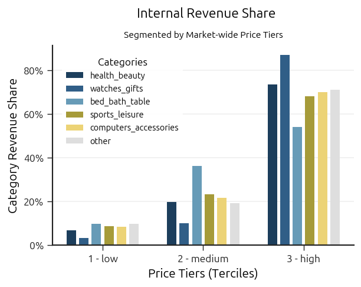

```python
plt.style.use(STYLE_PATH)
plt.rcParams.update({
    'figure.figsize': (5,4),
    'legend.fontsize': 9,
    'legend.title_fontsize': 10
})

custom_palette = [full_palette[0],full_palette[1],full_palette[2],full_palette[3],full_palette[4],'#DEDEDE']
custom_order = ["1 - low", "2 - medium", "3 - high"]
custom_hue_order = ["health_beauty","watches_gifts","bed_bath_table","sports_leisure","computers_accessories","other"]

ax = sns.barplot(data = df_q221, x = "price_tier", y = "category_revenue_share", hue = "market_segment",
            order = custom_order, hue_order = custom_hue_order,
            fill = True, gap = 0.25, width = .75, palette = custom_palette)

plt.legend(title = "Categories", loc = 'upper left', bbox_to_anchor=(0.02, 0.98), fontsize = 'small')
ax.yaxis.set_major_formatter(mtick.PercentFormatter(1.0))

plt.xlabel("Price Tiers (Terciles)")
plt.ylabel("Category Revenue Share")
plt.suptitle("Internal Revenue Share", fontsize = 13, fontweight = 'bold', y = 0.96, x = 0.57)
plt.title("Segmented by Market-wide Price Tiers", fontsize = 9, loc = 'center', pad = 8)

plt.tight_layout()

file_name = 'Fig2.2.2 Segmented by Market-wide Price Tiers - Internal Revenue Share.png'
save_path = os.path.join(FIGURES_PATH, file_name)
plt.savefig(save_path)
plt.show()
```

**Figure 2.2.1 & 2.2.2 - Observations**

Segmenting the product catalog into market-wide price terciles (Low, Medium, and High based on price distribution) yields a few crucial observations:

- The vast majority of Global Revenue Share is generated in the High Price Tier (*Fig 2.2.1*);
- Watches_Gifts is almost entirely a High Price Tier category, with over 80% of its internal revenue coming from the most expensive items (*Fig 2.2.2*).
- Bed_Bath_Table shows the most balanced distribution, with a significant presence in the Medium Tier (~35%), capturing a broader range of the market (*Fig 2.2.2*).
- The grey bars show that the broader market follows the same trend as the top categories, with revenue heavily skewed toward the high-priced tercile, confirming that the **platform's financial health is tied to expensive units**.

**Business Insight**

While the platform's traffic relies heavily on the Low Price Tier units, its contribution to the Global Revenue Share is almost negligible (*Fig 2.2.1*). This suggests that Low Tier items should be treated as **Customer Acquisition Tools**, while the High Tier items are the **Profit Engines**. This structure represents yet another platform's sensitivity - if inflation rises or consumer confidence drops, these High Tier revenues are the first at risk.

## Q3 Geographic Impact on Delivery Performance

This section analyzes the physical infrastructure of the platform, identifying regional bottlenecks and quantifying the financial consequences of logistical failures:

- **Q3.1** identifies the geographical regions where the logistics chain is slowest;
- **Q3.2** calculates the probability of fulfillment failure by visualizing the distribution of early versus late deliveries per state;
- **Q3.3** quantifies the Revenue at Risk to show the absolute financial exposure caused by delays in core vs. peripheral hubs.

### Q3.1 Median Delivery Time by Geographical State

```python
%%sql
--DROP VIEW IF EXISTS analytics.rpt_q3_state_delivery_estimation_reliability;
CREATE OR REPLACE VIEW analytics.rpt_q3_state_delivery_estimation_reliability AS
WITH base_metrics AS (
    SELECT
        COALESCE(s.seller_state, 'unknown') AS seller_state,
        o.order_sk,
        foi.price,
        (o.order_delivered_customer_t - o.order_approved_t) AS delivery_time_interval,
        CASE
            WHEN o.order_estimated_delivery_t::DATE > o.order_delivered_customer_t::DATE THEN '1 - early'
            WHEN o.order_estimated_delivery_t::DATE < o.order_delivered_customer_t::DATE THEN '3 - late'
            ELSE '2 - timely'
        END AS reliability
    FROM fact_order_items foi
    LEFT JOIN dim_orders o ON foi.order_sk = o.order_sk
    LEFT JOIN dim_sellers s ON foi.seller_sk = s.seller_sk
    WHERE o.order_delivered_customer_t IS NOT NULL AND o.order_approved_t IS NOT NULL
), aggregated_state_metrics AS (
    SELECT
        seller_state,
        reliability,
        COUNT(DISTINCT order_sk) AS deliveries_count,
        SUM(price) AS total_revenue,
        PERCENTILE_CONT(.5) WITHIN GROUP (ORDER BY delivery_time_interval) AS median_delivery_time_raw
    FROM base_metrics
    GROUP BY seller_state, reliability
)
SELECT
    seller_state,
    reliability,
    total_revenue,
    deliveries_count,
    ROUND(deliveries_count * 1.0 / SUM(deliveries_count) OVER(PARTITION BY seller_state), 4) AS perc_of_deliveries,
    ROUND(EXTRACT(EPOCH FROM median_delivery_time_raw) / 86400.0, 2) AS median_delivery_days
FROM aggregated_state_metrics
ORDER BY seller_state, reliability;
```

```python
df_q311 = pd.read_sql("SELECT * FROM analytics.rpt_q3_state_delivery_estimation_reliability;", engine)
```

**SQL Logic**

View: *rpt_q3_state_delivery_estimation_reliability*

This view evaluates the accuracy of delivery estimates and logistical speed across different Brazilian states to identify regional performance gaps and financial exposure:

- Mapping: I used the **COALESCE()** function to handle missing seller state metadata, providing an *unknown* fallback to maintain data completeness;
- Flag Identification: I implemented a **CASE WHEN** logic comparing estimated versus actual delivery dates to categorize every transaction into reliability tiers:
  - Tier 1 (*1 - early*);
  - Tier 2 (*2 - timely*);
  - Tier 3 (*3 - late*);
- Aggregation: I calculated the **COUNT(DISTINCT)** of order keys to determine *deliveries_count* and the **SUM()** of prices to establish the *total_revenue* per state and reliability group;
- Metrics: I used **PERCENTILE_CONT(0.5)** within each group to derive the *median_delivery_time_raw*; A window-based **SUM()** with a **PARTITION BY** clause to calculate the *perc_of_deliveries*, showing the internal distribution of reliability for each state;
- Temporal Grain: I implemented **EXTRACT(EPOCH FROM)** and division by 86400.0 to convert raw time intervals into a standardized *median_delivery_days* format.

This logic identifies geographical bottlenecks by normalizing delivery performance across regions with vastly different order volumes. By correlating reliability tiers with median days, the view provides a comprehensive audit of the platform's logistics promise versus actual physical fulfillment.

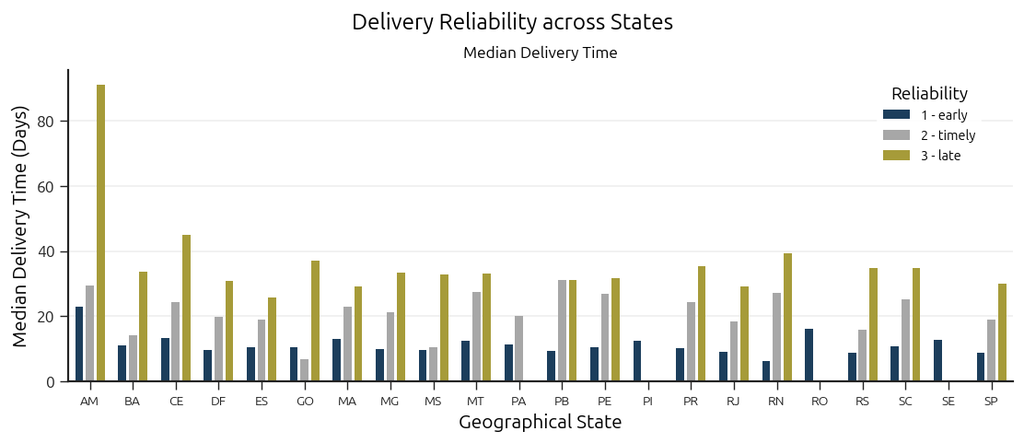

```python
plt.style.use(STYLE_PATH)
plt.rcParams.update({
    'figure.figsize': (9,4),
    'xtick.labelsize': 8
})

sns.barplot(data = df_q311, x = "seller_state", y = "median_delivery_days", hue = "reliability",
            palette = [full_palette[0],'#A7A7A7',full_palette[3]], fill = True, gap = 0.25, width = 0.75)

plt.legend(title = "Reliability", loc = 'upper left', bbox_to_anchor=(0.85, 0.99), fontsize = 'small')

plt.xlabel("Geographical State")
plt.ylabel("Median Delivery Time (Days)")
plt.suptitle("Delivery Reliability across States", fontsize = 14, fontweight = 'bold', y = 0.95, x = 0.5)
plt.title("Median Delivery Time", fontsize = 10, loc = 'center', pad = 8)

plt.tight_layout()

file_name = 'Fig3.1.1 Median Delivery Time.png'
save_path = os.path.join(FIGURES_PATH, file_name)
plt.savefig(save_path)
plt.show()
```

**Figure 3.1.1 - Observations**

This clustered bar chart categorizes deliveries into three reliability tiers (Early, Timely, and Late) revealing a significant variance in shipping performance across Brazil’s geography:

- States like **AM (Amazonas) exhibit extreme logistical problems**, with Late deliveries being frequent but also long (taking a median of over 90 days). This points to where the platform's delivaery estimation calculations must be improved.
- In almost every state, Early deliveries (Dark Blue) have a lower median time than Timely deliveries. This suggests that the **platform’s delivery estimates are conservative**.
- States like SP (São Paulo) and MG (Minas Gerais) show a more "compact" distribution. Their Late deliveries (Gold) are kept to a median of ~30 days, which, while still delayed, is significantly more controlled than the outliers.

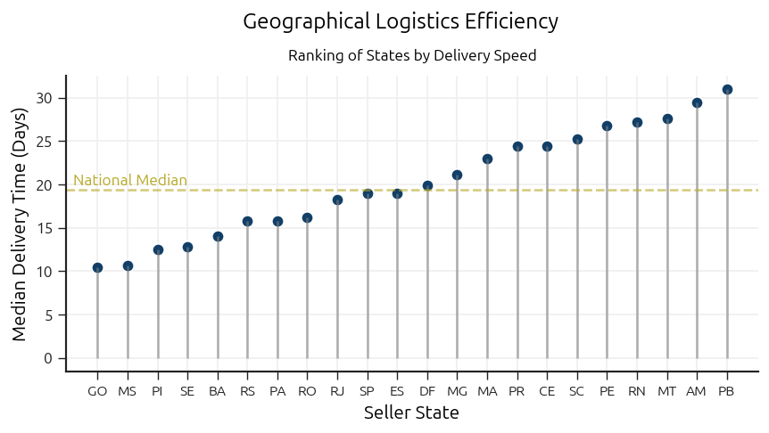

```python
plt.style.use(STYLE_PATH)
plt.rcParams.update({
    'figure.figsize': (7, 4),
    'xtick.labelsize': 9
})

df_q311_s = df_q311.groupby('seller_state')['median_delivery_days'].median().sort_values().reset_index()

fig, ax = plt.subplots()

ax.vlines(x = df_q311_s['seller_state'], ymin = 0, ymax = df_q311_s['median_delivery_days'],
          color = 'grey', alpha = 0.6, linewidth = 1.5)

ax.scatter(df_q311_s['seller_state'], df_q311_s['median_delivery_days'],
           color = full_palette[0], s = 60, edgecolors = "white", linewidth = 1)

national_median = df_q311_s['median_delivery_days'].median()
ax.axhline(national_median, color = full_palette[3], linestyle = '--', alpha = 0.6, linewidth = 1.5)
ax.text(len(df_q311_s)-19, national_median + 0.5, 'National Median',
        color = full_palette[3], fontsize = 10, ha = 'right')

plt.xlabel("Seller State")
plt.ylabel("Median Delivery Time (Days)")
plt.suptitle("Geographical Logistics Efficiency", fontsize = 14, fontweight = 'bold', y = 0.96, x = 0.52)
plt.title("Ranking of States by Delivery Speed", fontsize = 10, loc = 'center', pad = 10)

plt.tight_layout()

file_name = 'Fig3.1.2 Ranking of States by Delivery Speed.png'
save_path = os.path.join(FIGURES_PATH, file_name)
plt.savefig(save_path)
plt.show()
```

**Figure 3.1.2 - Observations**

The lollipop chart ranks states by their overall Median Delivery Time, providing a "speed leaderboard" for the platform's seller base:

- States like GO (Goiás), MS (Mato Grosso do Sul), and PI (Piauí) are the current **logistics champions**, maintaining median delivery times as low as 10–13 days, well below the National Median of ~19.5 days;
- DF (Distrito Federal) and ES (Espírito Santo) sit almost exactly on the **national median**, representing the standard logistics experience for the market;
- PB (Paraíba) and AM (Amazonas) represent **the slow end** of the spectrum, taking nearly 3x longer to reach customers compared to those in the top-ranked states.

**Business Insights**

The platform should **adjust the delivery time estimate to specific regions**: for an AM seller, the delivery time estimate needs to be significantly extended, while for a GO seller, it could be shortened to drive higher conversion.

The Late delivery median in states like AM and RN (Rio Grande do Norte) indicates a possible **lack of local distribution infrastructure**. Strategic partnerships with regional carriers or the establishment of platform's own hubs could drastically improve the platform's reliability.

### Q3.2 Delivery Reliability by Geographical State

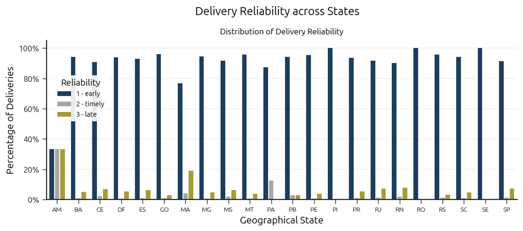

```python
plt.style.use(STYLE_PATH)
plt.rcParams.update({
    'figure.figsize': (9,4),
    'xtick.labelsize': 8
})

ax = sns.barplot(data = df_q311, x = "seller_state", y = "perc_of_deliveries", hue = "reliability",
            palette = [full_palette[0],'#A7A7A7',full_palette[3]], fill = True, gap = 0.15, width = 0.75)

plt.legend(title = "Reliability", loc = 'upper left', bbox_to_anchor=(0.01, 0.8), fontsize = 'small')
ax.yaxis.set_major_formatter(mtick.PercentFormatter(1.0))

plt.xlabel("Geographical State")
plt.ylabel("Percentage of Deliveries")
plt.suptitle("Delivery Reliability across States", fontsize = 14, fontweight = 'bold', y = 0.97, x = 0.53)
plt.title("Distribution of Delivery Reliability", fontsize = 10, loc = 'center', pad = 8)

plt.tight_layout()

file_name = 'Fig3.2.1 Distribution of Delivery Reliability.png'
save_path = os.path.join(FIGURES_PATH, file_name)
plt.savefig(save_path)
plt.show()
```

**Figure 3.2.1 - Observations**

**Business Insights**

The data suggests that a "One-Size-Fits-All" Service Level Agreement (SLA) is **damaging to the platform's reputation**. In states like PI (Piauí) or RO (Rondônia), where Early delivery rates are near 100%, the platform **could gain a competitiveness** by advertising faster shipping times. If a customer sees a 20-day estimate but receives it in 10, they are happy—but a different customer might have abandoned their cart because 20 days felt too long. Tightening these estimates in high-reliability states (SP, MG, GO) could unlock significant sales volume.

Conversely, for Amazonas, the platform should manage expectations by acknowledging a higher variance in fulfillment. Moreover, the small but consistent presence of **Late deliveries in SP (São Paulo, platform's highest volume hub) is more concerning** than the high percentage in AM. In SP, even a 5% Late rate impacts thousands more customers than a 30% rate in a low-volume Amazonas.

### Q3.3 Revenue at Risk Due to Late Deliveries

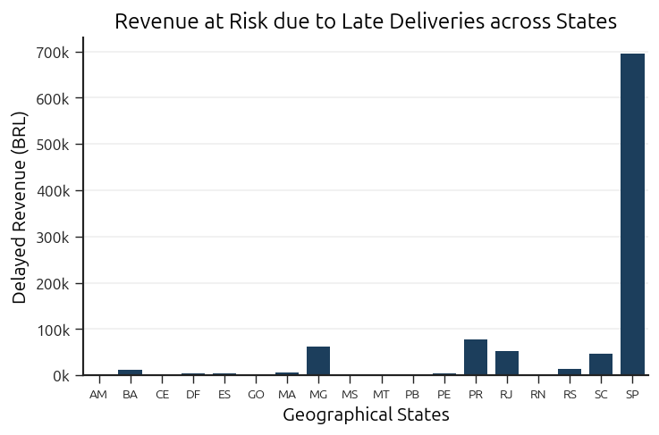

```python
plt.style.use(STYLE_PATH)
plt.rcParams.update({
    'figure.figsize': (6,4),
    'xtick.labelsize': 8
})

snapshot = df_q311[df_q311['reliability'] == '3 - late']

ax = sns.barplot(data = snapshot, x = "seller_state", y = "total_revenue",
            color = full_palette[0], fill = True, width = 0.75)

ax.yaxis.set_major_formatter(mtick.FuncFormatter(lambda x, pos: f'{x*1e-3:.0f}k'))

plt.xlabel("Geographical States")
plt.ylabel("Delayed Revenue (BRL)")
plt.title(f"Revenue at Risk due to Late Deliveries across States", loc = 'center')

plt.tight_layout()

file_name = 'Fig3.3.1 Revenue at Risk due to Late Deliveries across States.png'
save_path = os.path.join(FIGURES_PATH, file_name)
plt.savefig(save_path)
plt.show()
```

**Figure 3.3.1 - Observations**

This bar chart visualizes the absolute BRL value of transactions associated with late deliveries across Brazilian states. It reveals a dramatic concentration of financial risk:

- The **São Paulo's (SP)** general delivery reliability (*Fig 3.1.1, 3.1.2 and 3.2.1*) is offset by the fact that SP handles the vast majority of the platform's volume. Consequently, its relatively rare late deliveries account for nearly 700,000 BRL (~130,000 USD) in **"at-risk" revenue**;
- States like PR (Paraná), MG (Minas Gerais), and RJ (Rio de Janeiro) represent the next tier of financial risk, with delayed revenue falling between 50k and 80k BRL (~9,000-15,000 USD);
- Interestingly, **AM (Amazonas)**, which exhibited the poorest reliability and speed in previous charts, barely registers on this scale. This indicates that while the service is poor, the **total financial exposure there is minimal** compared to the core industrial hubs.

**Business Insights**

**São Paulo is a victim of its own success**. The volume is so high that even relatively minor inefficiencies result in massive amounts of capital at risk. From a business strategy perspective, a marginal improvement in SP's logistical efficiency is worth significantly more than a total overhaul in Amazonas. The platform should prioritize **logistics recovery efforts** in SP (e.g., premium carrier partnerships or dedicated sorting centers) to protect the highest-density revenue source first.

## Q4 Market Growth Trajectory & Revenue Momentum

This final section evaluates the temporal health of the platform, looking at growth velocity and seasonal stability to determine long-term market momentum:

### Q4.1 Monthly Revenue of Market Leaders

```python
%%sql
--DROP VIEW IF EXISTS analytics.rpt_q4_leaders_mom_growth;
CREATE OR REPLACE VIEW analytics.rpt_q4_leaders_mom_growth AS
WITH segmentation AS (
    SELECT
        COALESCE(ml.leader_label, 'residual') AS market_segment,
        TO_CHAR(o.order_purchase_t, 'YYYY-MM') AS monthly,
        foi.seller_sk,
        foi.price
    FROM fact_order_items foi
    LEFT JOIN dim_orders o ON foi.order_sk = o.order_sk
    LEFT JOIN analytics.int_market_leaders ml ON foi.seller_sk = ml.seller_sk
), monthly_revenue AS (
    SELECT
        market_segment,
        monthly,
        CASE
            WHEN market_segment = 'residual' THEN SUM(price) / NULLIF(COUNT(DISTINCT seller_sk), 0)
            ELSE SUM(price)
        END AS this_month_revenue
    FROM segmentation
    GROUP BY monthly, market_segment
), rolling_monthly_revenue AS (
    SELECT
        market_segment,
        monthly,
        this_month_revenue,
        LAG(this_month_revenue, 1) OVER (
            PARTITION BY market_segment ORDER BY monthly)
            AS prior_month_revenue,
        AVG(this_month_revenue) OVER (
            PARTITION BY market_segment ORDER BY monthly ROWS BETWEEN 2 PRECEDING AND CURRENT ROW)
            AS T3M_revenue
    FROM monthly_revenue
)
SELECT
    market_segment,
    monthly,
    this_month_revenue,
    prior_month_revenue,
    T3M_revenue,
    ROUND(((this_month_revenue - prior_month_revenue) / NULLIF(prior_month_revenue, 0) * 100), 2)
        AS mom_growth_pct
FROM rolling_monthly_revenue
WHERE prior_month_revenue IS NOT NULL
ORDER BY market_segment, monthly;
```

```python
df_q411 = pd.read_sql("SELECT * FROM analytics.rpt_q4_leaders_mom_growth;", engine)
df_q411['monthly'] = pd.to_datetime(df_q411['monthly']).dt.strftime('%Y-%m')
df_q411 = df_q411.sort_values('monthly')
```

**SQL Logic**

View: *rpt_q4_leaders_mom_growth*

This view evaluates the revenue velocity and momentum of market segments by calculating Month-over-Month (MoM) growth rates and smoothing short-term volatility with trailing averages:

- Market Segmentation: I used the *COALESCE()* function to map merchants to specific leader labels while grouping all non-leader sellers into a *residual* baseline;
- Temporal Grain: I utilized the *TO_CHAR()* function to format transaction timestamps into a standardized YYYY-MM *monthly* identifier;
- Aggregation: I calculated the **SUM()** of prices to determine revenue. Within the *residual* segment, I implemented a division by the **COUNT(DISTINCT)** of sellers to derive an average revenue per merchant, ensuring a normalized comparison against individual market leaders;
- Metrics:
  - **LAG()** window function partitioned by *market_segment* calculated the *prior_month_revenue*;
  - **AVG()** window function with a **ROWS BETWEEN 2 PRECEDING AND CURRENT ROW** clause calculated the *T3M_revenue* (Trailing 3-Month average);
  - standard percentage calculations resulted in *mom_growth_pct*.

This logic provides a sophisticated momentum analysis by combining raw growth rates with a 3-month rolling average to filter out seasonal noise. By normalizing the residual market as an "average merchant," the view allows for a direct competitive assessment of whether market leaders are truly outperforming the general population.

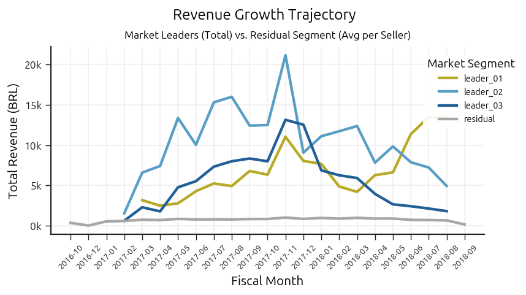

```python
plt.style.use(STYLE_PATH)
plt.rcParams.update({
    'figure.figsize': (7,4),
    'xtick.labelsize': 8
})

custom_palette = [full_palette[3],full_palette[2],full_palette[1],"#A7A7A7"]

ax = sns.lineplot(data = df_q411, x = 'monthly', y = 'this_month_revenue', hue = 'market_segment',
    hue_order = ["leader_01", "leader_02", "leader_03", "residual"], palette = custom_palette, linewidth = 2.5)

plt.legend(title = "Market Segment", loc = 'upper left', bbox_to_anchor=(0.85, 0.98), fontsize = 'small')
ax.yaxis.set_major_formatter(mtick.FuncFormatter(lambda x, pos: f'{x*1e-3:.0f}k'))
ax.set_xticks(range(len(df_q411['monthly'].unique())))
ax.set_xticklabels(df_q411['monthly'].unique(), rotation = 45)

plt.xlabel("Fiscal Month")
plt.ylabel("Total Revenue (BRL)")
plt.suptitle("Revenue Growth Trajectory", fontsize = 14, fontweight = 'bold', y = 0.95, x = 0.5)
plt.title("Market Leaders (Total) vs. Residual Segment (Avg per Seller)", fontsize = 10, loc = 'center', pad = 8)

plt.tight_layout()

file_name = 'Fig4.1.1 Revenue Growth Trajectory.png'
save_path = os.path.join(FIGURES_PATH, file_name)
plt.savefig(save_path)
plt.show()
```

**Figure 4.1.1 - Observations**

The line chart reveals a high degree of volatility among market leaders compared to the extreme stability of the residual segment. While the general market average remains flat, individual leaders experience dramatic revenue swings:

- **Leader 02** demonstrates the most aggressive growth trajectory, reaching a significant peak in November 2017 with over 20,000 BRL (~3,700 USD) in monthly revenue. However, this peak was followed by a sharp correction, highlighting a lack of sustainable momentum;
- **Leader 01** shows a distinct recovery pattern in mid-2018. After a period of stagnation and decline following the 2017 peak, it is the only segment trending upward by August 2018, eventually overtaking the other leaders;
- The **Residual** baseline exhibits near-zero variance. Because this metric represents the average per seller, it indicates that the typical merchant on the platform operates at a very low, static revenue ceiling, unaffected by the seasonal surges that impact the leaders.

All three leaders show a synchronized spike in November 2017, confirming a strong platform-wide Black Friday seasonality effect, though the magnitude of impact varied significantly between them.

**Business Insights**

The platform exhibits **a top-heavy volatility** characteristic of a maturing marketplace. The fact that the residual average does not mirror the Leaders' growth suggests that the logistical and marketing "uplift" of peak seasons is primarily captured by a few players. From a strategic standpoint, the platform’s overall health is complicated; the **stagnation of the residual segment** points to a lack of "middle-class" seller growth, meaning the platform’s GMV remains highly sensitive to the performance of just three individual entities.

### Q4.2 MoM Growth Rate of Market Leaders

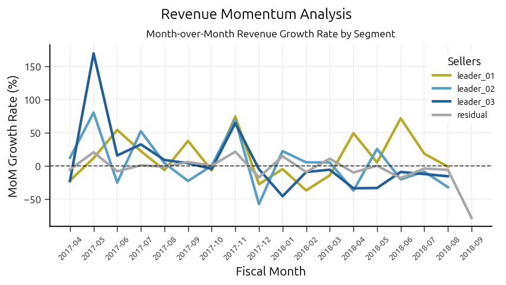

```python
plt.style.use(STYLE_PATH)
plt.rcParams.update({
    'figure.figsize': (7,4),
    'xtick.labelsize': 8
})

custom_palette = [full_palette[3],full_palette[2],full_palette[1],"#A7A7A7"]

burnin_start = "2017-03"

df_q411_s = df_q411[df_q411["monthly"] > burnin_start]

ax = sns.lineplot(data = df_q411_s, x = 'monthly', y = 'mom_growth_pct', hue = 'market_segment',
    hue_order = ["leader_01", "leader_02", "leader_03", "residual"], palette = custom_palette, linewidth = 2.5)

plt.legend(title = "Sellers", loc = 'upper left', bbox_to_anchor=(0.85, 0.98), fontsize = 'small')
ax.axhline(0, color = 'black', linestyle = '--', linewidth = 1, alpha = 0.7)
ax.set_xticks(range(len(df_q411_s['monthly'].unique())))
ax.set_xticklabels(df_q411_s['monthly'].unique(), rotation = 45)

plt.xlabel("Fiscal Month")
plt.ylabel("MoM Growth Rate (%)")
plt.suptitle("Revenue Momentum Analysis", fontsize = 14, fontweight = 'bold', y = 0.95, x = 0.5)
plt.title("Month-over-Month Revenue Growth Rate by Segment", fontsize = 10, loc = 'center', pad = 8)

plt.tight_layout()

file_name = 'Fig4.2.1 Revenue Momentum Analysis.png'
save_path = os.path.join(FIGURES_PATH, file_name)
plt.savefig(save_path)
plt.show()
```

**Figure 4.2.1 - Observations**

This visualization shifts the focus from absolute revenue to growth velocity, plotting the Month-over-Month (MoM) percentage changes to identify periods of momentum and contraction:

- The period of May 2017 shows an unprecedented growth spike for **Leader 03** exceeding 150%, likely representing a **low-base effect** where a small absolute increase in orders results in a massive percentage surge;
- All segments, including the Residual group, show a **positive growth correlation** in November 2017 (possibly the Black Friday effect). Leader 01 and Leader 02 captured the highest relative momentum during this window. December 2017 shows a **universal "growth hangover"** where all segments fell into negative territory. Leader 02 suffered the most significant contraction, dropping nearly 60% MoM, indicating a high dependency on holiday-driven sales;
- The Residual segment maintains a growth rate closest to the 0% baseline for most of the timeline, suggesting a **mature but slow-moving market**. The sharp drop in September 2018 likely reflects a data cutoff or systemic platform event rather than individual seller failure.

**Business Insights**

The MoM analysis reveals that **market leadership is inherently unstable**. No single Leader has established a sustainable month-to-month dominance strategy. However, Leader 01's resilience in the final quarters suggests a shift toward non-seasonal growth. Conversely, the swings of Leader 02 and Leader 03 indicate an over-reliance on platform-wide promotions.

For the platform, **the primary risk is momentum exhaustion**: after the 2017 holiday surge, the "return to baseline" for most Leaders was deeper and longer than expected, suggesting that peak-season customers are not being successfully converted into year-round recurring revenue.

> *Note on Methodology: To ensure the statistical integrity of the MoM growth measure, a burn-in period was implemented. Data prior to March 2017 was excluded to eliminate extreme outliers caused by the platform's initial setup phase.*

### Q4.3 Trailing 3 Month Revenue of Market Leaders

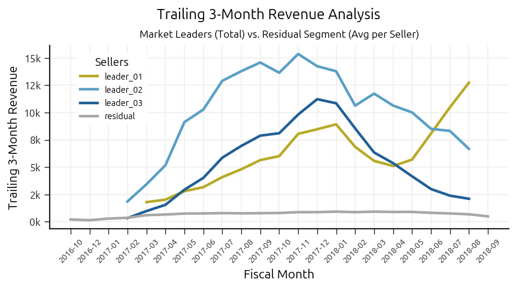

```python
plt.style.use(STYLE_PATH)
plt.rcParams.update({
    'figure.figsize': (7,4),
    'xtick.labelsize': 8
})

custom_palette = [full_palette[3],full_palette[2],full_palette[1],"#A7A7A7"]

ax = sns.lineplot(data = df_q411, x = 'monthly', y = 't3m_revenue', hue = 'market_segment',
    hue_order = ["leader_01", "leader_02", "leader_03", "residual"], palette = custom_palette, linewidth = 2.5)

plt.legend(title = "Sellers", loc = 'upper left', bbox_to_anchor=(0.05, 0.98), fontsize = 'small')
ax.yaxis.set_major_formatter(mtick.FuncFormatter(lambda x, pos: f'{x*1e-3:.0f}k'))
ax.set_xticks(range(len(df_q411['monthly'].unique())))
ax.set_xticklabels(df_q411['monthly'].unique(), rotation = 45)

plt.xlabel("Fiscal Month")
plt.ylabel("Trailing 3-Month Revenue")
plt.suptitle("Trailing 3-Month Revenue Analysis", fontsize = 14, fontweight = 'bold', y = 0.95, x = 0.52)
plt.title("Market Leaders (Total) vs. Residual Segment (Avg per Seller)", fontsize = 10, loc = 'center', pad = 8)

plt.tight_layout()

file_name = 'Fig4.3.1 Trailing 3-Month Revenue Analysis.png'
save_path = os.path.join(FIGURES_PATH, file_name)
plt.savefig(save_path)
plt.show()
```

**Figure 4.3.1 - Observations**

The Trailing 3-Month (T3M) analysis filters out high-frequency monthly noise to reveal the underlying structural trends of each market segment:

- **Leader 02** shows a sustained period of dominance throughout 2017, reaching a smoothed peak of over 15,000 BRL (~2,800 USD). Unlike the volatile spikes seen in the raw monthly data, the T3M view confirms that this seller maintained **a high-revenue plateau** for nearly six months before entering a structural decline in early 2018;
- **Leader 01** demonstrates a **remarkable recovery**. After losing ground to the other Leaders in late 2017, it shows a steep, sustained upward trajectory starting in May 2018. It is the only segment to finish the analyzed period with a positive trend;
- The T3M smoothing reveals that **Leader 03's decline was a consistent downward trend** starting from December 2017;
- The **Residual** average remains essentially flat across the entire timeline.

**Business Insights**

The T3M analysis provides the most accurate view of long-term viability. The divergence between Leader 01 and the other segments in 2018 suggests a fundamental difference in operational strategy. **The "Residual Stagnation"** is a significant strategic concern; it suggests the platform lacks a "growth engine" for small-to-medium sellers, creating a high-risk dependency on the top 0.1% of the merchant base. From a platform health perspective, **the decline of two out of three major Leaders** in 2018 indicates that the marketplace is currently at risk.

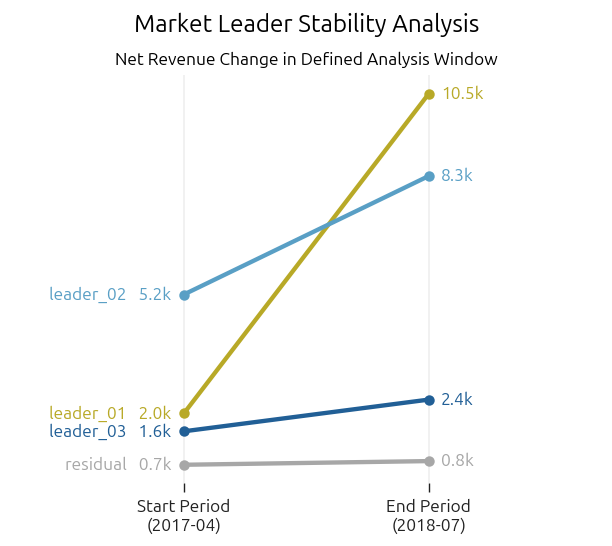

```python
start_month = '2017-04'
end_month = '2018-07'

df_q411_s = df_q411[df_q411['monthly'].isin([start_month, end_month])]
df_q411_sp = df_q411_s.pivot(index = 'market_segment', columns = 'monthly', values = 't3m_revenue')
df_q411_sp.columns = ['Start', 'End']

plt.style.use(STYLE_PATH)
fig, ax = plt.subplots(figsize = (5, 4.5))

segments = ["leader_01", "leader_02", "leader_03", "residual"]
colors = [full_palette[3], full_palette[2], full_palette[1], "#A7A7A7"]

for i, segment in enumerate(segments):
    if segment in df_q411_sp.index:
        y_start = df_q411_sp.loc[segment, 'Start']
        y_end = df_q411_sp.loc[segment, 'End']

        ax.plot([0, 1], [y_start, y_end], marker = 'o', color = colors[i], linewidth = 2.5)

        ax.text(-0.05, y_start, f'{segment}   {y_start*1e-3:.1f}k',
                ha = 'right', va = 'center', fontsize = 10, fontweight = 'bold', color = colors[i])
        ax.text(1.05, y_end, f'{y_end*1e-3:.1f}k',
                ha = 'left', va = 'center', fontsize = 10, fontweight = 'bold', color = colors[i])

ax.set_xlim(-0.7, 1.7)
ax.set_xticks([0, 1])
ax.set_xticklabels([f'Start Period\n({start_month})', f'End Period\n({end_month})'], fontsize = 10, fontweight = 'bold')
ax.get_yaxis().set_visible(False)

for spine in ["top", "right", "left", "bottom"]:
    ax.spines[spine].set_visible(False)

plt.suptitle("Market Leader Stability Analysis", fontsize = 14, fontweight = 'bold', y = 0.96, x = 0.5)
plt.title("Net Revenue Change in Defined Analysis Window", fontsize = 10, loc = 'center', pad = 6)

plt.tight_layout()

file_name = 'Fig4.3.2 Market Leader Stability Analysis.png'
save_path = os.path.join(FIGURES_PATH, file_name)
plt.savefig(save_path)
plt.show()
```

**Figure 4.3.2 - Observations**

**Business Insights**

The stability analysis confirms that the marketplace is undergoing **a process of intense concentration**. The primary engine of platform growth is not a rising tide for all sellers, but rather the rapid expansion of a very small group of leaders. Leader 01's trajectory suggests a "winner-takes-all" dynamic where superior operational efficiency or category dominance allows a single entity to capture the hige share of new market growth.

> *Note on Methodology: The analysis window for this comparison was set between April 2017 - chosen to bypass the initial platform "burn-in" period - and July 2018 - chosen to provide the most recent complete data cycle before the platform-wide volume drop observed in late 2018.*

## Summary

**Market Dynamics and Operational Stability (Q1 & Q4)**

The analysis of **Market Leaders** and their growth trajectories reveals a platform defined by high transaction velocity but significant operational variance. While the Three Leaders command substantial revenue, their growth patterns often diverge from the broader market, showing **a higher susceptibility to logistical shocks and supply chain friction**.

Q4 specific results indicate that while the platform achieved a 15-month peak in gross revenue, the Month-over-Month (MoM) growth rates exhibit high instability. The Trailing 3-Month (T3M) smoothing confirms that the rapid expansion phase was not uniform. Rather, it was characterized by "growth spurts" followed by significant consolidation periods. This suggests that the **platform's scalability is currently reactive to seasonal peaks** rather than driven by a sustained, linear increase in baseline seller performance.

**Product Efficiency and Regional Financial Risk (Q2 & Q3)**

The marketplace demonstrates a distribution, where 40% of revenue is concentrated in just five key categories, predominantly driven by high-ticket items in the upper price terciles. While mass-market volume thrives in low-to-mid price points, the **platform’s financial health is disproportionately tied to High-Yield categories** like Watches_Gifts, which offer superior revenue-to-volume ratios.

**Conclusions - General Trends**

**Revenue Polarisation**: the platform's success is heavily reliant on a small cohort of Market Leaders and High-Yield categories, creating a structural dependency that increases systemic risk.

**Logistical Disconnect**: there is a persistent gap between revenue growth and delivery reliability. High volume does not currently correlate with operational excellence, suggesting that scaling has outpaced infrastructure development.

**Regional Asymmetry**: the Olist market remains deeply polarised. Logistics in the Southeast (SP,RJ) drive financial stability, while Northern regions act as high-friction zones that dilute overall platform KPIs.

**Methodological Limitations**

- The 100,000-order snapshot is **a historical "frozen" dataset** (2016–2018), which may not reflect recent post-pandemic shifts in Brazilian e-commerce behavior or logistics technology;
- Models do not account for **external macroeconomic factors** such as BRL exchange rate volatility, national strikes, or changes in postal service pricing structures during the window;
- The current SQL views treat **cancelled orders** as lost revenue but cannot distinguish between seller-fault cancellations and customer-driven returns, potentially overstating seller-side failure rates;
- The T3M and MoM growth models assume a degree of continuity that may **overlook micro-seasonal events** (e.g., local holidays) not explicitly flagged in the primary timestamp data.